# Project: Identify Customer Segments

In this project, you will apply unsupervised learning techniques to identify segments of the population that form the core customer base for a mail-order sales company in Germany. These segments can then be used to direct marketing campaigns towards audiences that will have the highest expected rate of returns. The data that you will use has been provided by our partners at Bertelsmann Arvato Analytics, and represents a real-life data science task.

This notebook will help you complete this task by providing a framework within which you will perform your analysis steps. In each step of the project, you will see some text describing the subtask that you will perform, followed by one or more code cells for you to complete your work. **Feel free to add additional code and markdown cells as you go along so that you can explore everything in precise chunks.** The code cells provided in the base template will outline only the major tasks, and will usually not be enough to cover all of the minor tasks that comprise it.

It should be noted that while there will be precise guidelines on how you should handle certain tasks in the project, there will also be places where an exact specification is not provided. **There will be times in the project where you will need to make and justify your own decisions on how to treat the data.** These are places where there may not be only one way to handle the data. In real-life tasks, there may be many valid ways to approach an analysis task. One of the most important things you can do is clearly document your approach so that other scientists can understand the decisions you've made.

At the end of most sections, there will be a Markdown cell labeled **Discussion**. In these cells, you will report your findings for the completed section, as well as document the decisions that you made in your approach to each subtask. **Your project will be evaluated not just on the code used to complete the tasks outlined, but also your communication about your observations and conclusions at each stage.**

```python
# import libraries here; add more as necessary
import numpy as np
import pandas as pd
import matplotlib.pyplot as plt
import seaborn as sns

# magic word for producing visualizations in notebook
%matplotlib inline

'''
Import note: The classroom currently uses sklearn version 0.19.
If you need to use an imputer, it is available in sklearn.preprocessing.Imputer,
instead of sklearn.impute as in newer versions of sklearn.
'''
```

```
'\nImport note: The classroom currently uses sklearn version 0.19.\nIf you need to use an imputer, it is available in sklearn.preprocessing.Imputer,\ninstead of sklearn.impute as in newer versions of sklearn.\n'
```

### Step 0: Load the Data

Each row of the demographics files represents a single person, but also includes information outside of individuals, including information about their household, building, and neighborhood. You will use this information to cluster the general population into groups with similar demographic properties. Then, you will see how the people in the customers dataset fit into those created clusters. The hope here is that certain clusters are over-represented in the customers data, as compared to the general population; those over-represented clusters will be assumed to be part of the core userbase. This information can then be used for further applications, such as targeting for a marketing campaign.

To start off with, load in the demographics data for the general population into a pandas DataFrame, and do the same for the feature attributes summary. Note for all of the `.csv` data files in this project: they're semicolon (`;`) delimited, so you'll need an additional argument in your [`read_csv()`](https://pandas.pydata.org/pandas-docs/stable/generated/pandas.read_csv.html) call to read in the data properly. Also, considering the size of the main dataset, it may take some time for it to load completely.

Once the dataset is loaded, it's recommended that you take a little bit of time just browsing the general structure of the dataset and feature summary file. You'll be getting deep into the innards of the cleaning in the first major step of the project, so gaining some general familiarity can help you get your bearings.

```python
# Load in the general demographics data.
azdias = pd.read_csv("Udacity_AZDIAS_Subset.csv",delimiter=';')

# Load in the feature summary file.
feat = pd.read_csv("AZDIAS_Feature_Summary.csv",delimiter=';')
```

```python
# Check the structure of the data after it's loaded (e.g. print the number of
# rows and columns, print the first few rows).
azdias.head()
```

|  | AGER_TYP | ALTERSKATEGORIE_GROB | ANREDE_KZ | CJT_GESAMTTYP | FINANZ_MINIMALIST | FINANZ_SPARER | FINANZ_VORSORGER | FINANZ_ANLEGER | FINANZ_UNAUFFAELLIGER | FINANZ_HAUSBAUER | ... | PLZ8_ANTG1 | PLZ8_ANTG2 | PLZ8_ANTG3 | PLZ8_ANTG4 | PLZ8_BAUMAX | PLZ8_HHZ | PLZ8_GBZ | ARBEIT | ORTSGR_KLS9 | RELAT_AB |
| --- | --- | --- | --- | --- | --- | --- | --- | --- | --- | --- | --- | --- | --- | --- | --- | --- | --- | --- | --- | --- | --- |
| 0 | -1 | 2 | 1 | 2.0 | 3 | 4 | 3 | 5 | 5 | 3 | ... | NaN | NaN | NaN | NaN | NaN | NaN | NaN | NaN | NaN | NaN |
| 1 | -1 | 1 | 2 | 5.0 | 1 | 5 | 2 | 5 | 4 | 5 | ... | 2.0 | 3.0 | 2.0 | 1.0 | 1.0 | 5.0 | 4.0 | 3.0 | 5.0 | 4.0 |
| 2 | -1 | 3 | 2 | 3.0 | 1 | 4 | 1 | 2 | 3 | 5 | ... | 3.0 | 3.0 | 1.0 | 0.0 | 1.0 | 4.0 | 4.0 | 3.0 | 5.0 | 2.0 |
| 3 | 2 | 4 | 2 | 2.0 | 4 | 2 | 5 | 2 | 1 | 2 | ... | 2.0 | 2.0 | 2.0 | 0.0 | 1.0 | 3.0 | 4.0 | 2.0 | 3.0 | 3.0 |
| 4 | -1 | 3 | 1 | 5.0 | 4 | 3 | 4 | 1 | 3 | 2 | ... | 2.0 | 4.0 | 2.0 | 1.0 | 2.0 | 3.0 | 3.0 | 4.0 | 6.0 | 5.0 |

5 rows × 85 columns

```python
azdias.describe()
```

|  | AGER_TYP | ALTERSKATEGORIE_GROB | ANREDE_KZ | CJT_GESAMTTYP | FINANZ_MINIMALIST | FINANZ_SPARER | FINANZ_VORSORGER | FINANZ_ANLEGER | FINANZ_UNAUFFAELLIGER | FINANZ_HAUSBAUER | ... | PLZ8_ANTG1 | PLZ8_ANTG2 | PLZ8_ANTG3 | PLZ8_ANTG4 | PLZ8_BAUMAX | PLZ8_HHZ | PLZ8_GBZ | ARBEIT | ORTSGR_KLS9 | RELAT_AB |
| --- | --- | --- | --- | --- | --- | --- | --- | --- | --- | --- | --- | --- | --- | --- | --- | --- | --- | --- | --- | --- | --- |
| count | 891221.000000 | 891221.000000 | 891221.000000 | 886367.000000 | 891221.000000 | 891221.000000 | 891221.000000 | 891221.000000 | 891221.000000 | 891221.000000 | ... | 774706.000000 | 774706.000000 | 774706.000000 | 774706.000000 | 774706.000000 | 774706.000000 | 774706.000000 | 794005.000000 | 794005.000000 | 794005.00000 |
| mean | -0.358435 | 2.777398 | 1.522098 | 3.632838 | 3.074528 | 2.821039 | 3.401106 | 3.033328 | 2.874167 | 3.075121 | ... | 2.253330 | 2.801858 | 1.595426 | 0.699166 | 1.943913 | 3.612821 | 3.381087 | 3.167854 | 5.293002 | 3.07222 |
| std | 1.198724 | 1.068775 | 0.499512 | 1.595021 | 1.321055 | 1.464749 | 1.322134 | 1.529603 | 1.486731 | 1.353248 | ... | 0.972008 | 0.920309 | 0.986736 | 0.727137 | 1.459654 | 0.973967 | 1.111598 | 1.002376 | 2.303739 | 1.36298 |
| min | -1.000000 | 1.000000 | 1.000000 | 1.000000 | 1.000000 | 1.000000 | 1.000000 | 1.000000 | 1.000000 | 1.000000 | ... | 0.000000 | 0.000000 | 0.000000 | 0.000000 | 1.000000 | 1.000000 | 1.000000 | 1.000000 | 0.000000 | 1.00000 |
| 25% | -1.000000 | 2.000000 | 1.000000 | 2.000000 | 2.000000 | 1.000000 | 3.000000 | 2.000000 | 2.000000 | 2.000000 | ... | 1.000000 | 2.000000 | 1.000000 | 0.000000 | 1.000000 | 3.000000 | 3.000000 | 3.000000 | 4.000000 | 2.00000 |
| 50% | -1.000000 | 3.000000 | 2.000000 | 4.000000 | 3.000000 | 3.000000 | 3.000000 | 3.000000 | 3.000000 | 3.000000 | ... | 2.000000 | 3.000000 | 2.000000 | 1.000000 | 1.000000 | 4.000000 | 3.000000 | 3.000000 | 5.000000 | 3.00000 |
| 75% | -1.000000 | 4.000000 | 2.000000 | 5.000000 | 4.000000 | 4.000000 | 5.000000 | 5.000000 | 4.000000 | 4.000000 | ... | 3.000000 | 3.000000 | 2.000000 | 1.000000 | 3.000000 | 4.000000 | 4.000000 | 4.000000 | 7.000000 | 4.00000 |
| max | 3.000000 | 9.000000 | 2.000000 | 6.000000 | 5.000000 | 5.000000 | 5.000000 | 5.000000 | 5.000000 | 5.000000 | ... | 4.000000 | 4.000000 | 3.000000 | 2.000000 | 5.000000 | 5.000000 | 5.000000 | 9.000000 | 9.000000 | 9.00000 |

8 rows × 81 columns

```python
feat.head()
```

|  | attribute | information_level | type | missing_or_unknown |
| --- | --- | --- | --- | --- |
| 0 | AGER_TYP | person | categorical | [-1,0] |
| 1 | ALTERSKATEGORIE_GROB | person | ordinal | [-1,0,9] |
| 2 | ANREDE_KZ | person | categorical | [-1,0] |
| 3 | CJT_GESAMTTYP | person | categorical | [0] |
| 4 | FINANZ_MINIMALIST | person | ordinal | [-1] |

```python
feat.describe()
```

|  | attribute | information_level | type | missing_or_unknown |
| --- | --- | --- | --- | --- |
| count | 85 | 85 | 85 | 85 |
| unique | 85 | 9 | 5 | 9 |
| top | LP_LEBENSPHASE_GROB | person | ordinal | [-1] |
| freq | 1 | 43 | 49 | 26 |

> **Tip**: Add additional cells to keep everything in reasonably-sized chunks! Keyboard shortcut `esc --> a` (press escape to enter command mode, then press the 'A' key) adds a new cell before the active cell, and `esc --> b` adds a new cell after the active cell. If you need to convert an active cell to a markdown cell, use `esc --> m` and to convert to a code cell, use `esc --> y`.

## Step 1: Preprocessing

### Step 1.1: Assess Missing Data

The feature summary file contains a summary of properties for each demographics data column. You will use this file to help you make cleaning decisions during this stage of the project. First of all, you should assess the demographics data in terms of missing data. Pay attention to the following points as you perform your analysis, and take notes on what you observe. Make sure that you fill in the **Discussion** cell with your findings and decisions at the end of each step that has one!

#### Step 1.1.1: Convert Missing Value Codes to NaNs

The fourth column of the feature attributes summary (loaded in above as `feat_info`) documents the codes from the data dictionary that indicate missing or unknown data. While the file encodes this as a list (e.g. `[-1,0]`), this will get read in as a string object. You'll need to do a little bit of parsing to make use of it to identify and clean the data. Convert data that matches a 'missing' or 'unknown' value code into a numpy NaN value. You might want to see how much data takes on a 'missing' or 'unknown' code, and how much data is naturally missing, as a point of interest.

**As one more reminder, you are encouraged to add additional cells to break up your analysis into manageable chunks.**

```python
missing=feat['missing_or_unknown'].to_dict()
attr=feat['attribute'].to_dict()
attr_missing={}

#get missing attrs
for ft in range(len(feat)):
    list_missing_vals = missing[ft].strip('[]').split(',') #in str list e.g. ['-1','0','X']
    attr_name = attr[ft]
    print(f"attr: {attr_name}, missing values as list: {list_missing_vals}")
    try:
        # if ['-1','0'], treat it as [-1,0]
        replaceable=azdias.loc[azdias[attr_name].isin([int(s) for s in list_missing_vals]),attr_name].count()
        print(f"\t {replaceable} will be replaced")
        azdias[attr_name].replace([int(s) for s in list_missing_vals],np.nan,inplace=True)

        #safekeeping (attr_name,amount of missing/unknown data)
        attr_missing[attr_name] = replaceable
    except ValueError:
        # if ['-1','X'] keep it as-is (str)
        print('\t continue')
        replaceable = azdias.loc[azdias[attr_name].isin(list_missing_vals),attr_name].count()
        print(f"\t {replaceable} will be replaced")
        azdias[attr_name].replace(list_missing_vals,np.nan,inplace=True)

        #safekeeping (attr_name,amount of missing/unknown data)
        attr_missing[attr_name] = replaceable
```

```
attr: AGER_TYP, missing values as list: ['-1', '0']
	 685843 will be replaced
attr: ALTERSKATEGORIE_GROB, missing values as list: ['-1', '0', '9']
	 2881 will be replaced
attr: ANREDE_KZ, missing values as list: ['-1', '0']
	 0 will be replaced
attr: CJT_GESAMTTYP, missing values as list: ['0']
	 0 will be replaced
attr: FINANZ_MINIMALIST, missing values as list: ['-1']
	 0 will be replaced
attr: FINANZ_SPARER, missing values as list: ['-1']
	 0 will be replaced
attr: FINANZ_VORSORGER, missing values as list: ['-1']
	 0 will be replaced
attr: FINANZ_ANLEGER, missing values as list: ['-1']
	 0 will be replaced
attr: FINANZ_UNAUFFAELLIGER, missing values as list: ['-1']
	 0 will be replaced
attr: FINANZ_HAUSBAUER, missing values as list: ['-1']
	 0 will be replaced
attr: FINANZTYP, missing values as list: ['-1']
	 0 will be replaced
attr: GEBURTSJAHR, missing values as list: ['0']
	 392318 will be replaced
attr: GFK_URLAUBERTYP, missing values as list: ['']
	 continue
	 0 will be replaced
attr: GREEN_AVANTGARDE, missing values as list: ['']
	 continue
	 0 will be replaced
attr: HEALTH_TYP, missing values as list: ['-1', '0']
	 111196 will be replaced
attr: LP_LEBENSPHASE_FEIN, missing values as list: ['0']
	 92778 will be replaced
attr: LP_LEBENSPHASE_GROB, missing values as list: ['0']
	 89718 will be replaced
attr: LP_FAMILIE_FEIN, missing values as list: ['0']
	 72938 will be replaced
attr: LP_FAMILIE_GROB, missing values as list: ['0']
	 72938 will be replaced
```

[output cut: 128 more lines]

```
	 0 will be replaced
attr: PLZ8_ANTG4, missing values as list: ['-1']
	 0 will be replaced
attr: PLZ8_BAUMAX, missing values as list: ['-1', '0']
	 0 will be replaced
attr: PLZ8_HHZ, missing values as list: ['-1']
	 0 will be replaced
attr: PLZ8_GBZ, missing values as list: ['-1']
	 0 will be replaced
attr: ARBEIT, missing values as list: ['-1', '9']
	 159 will be replaced
attr: ORTSGR_KLS9, missing values as list: ['-1', '0']
	 58 will be replaced
attr: RELAT_AB, missing values as list: ['-1', '9']
	 159 will be replaced
```

```python
#check the amount of missings in each feature
print("Missings amount in each feature:")
attr_missing
```

```
Missings amount in each feature:
```

```
{'AGER_TYP': 685843,
 'ALTERSKATEGORIE_GROB': 2881,
 'ANREDE_KZ': 0,
 'CJT_GESAMTTYP': 0,
 'FINANZ_MINIMALIST': 0,
 'FINANZ_SPARER': 0,
 'FINANZ_VORSORGER': 0,
 'FINANZ_ANLEGER': 0,
 'FINANZ_UNAUFFAELLIGER': 0,
 'FINANZ_HAUSBAUER': 0,
 'FINANZTYP': 0,
 'GEBURTSJAHR': 392318,
 'GFK_URLAUBERTYP': 0,
 'GREEN_AVANTGARDE': 0,
 'HEALTH_TYP': 111196,
 'LP_LEBENSPHASE_FEIN': 92778,
 'LP_LEBENSPHASE_GROB': 89718,
 'LP_FAMILIE_FEIN': 72938,
 'LP_FAMILIE_GROB': 72938,
 'LP_STATUS_FEIN': 0,
 'LP_STATUS_GROB': 0,
 'NATIONALITAET_KZ': 108315,
 'PRAEGENDE_JUGENDJAHRE': 108164,
 'RETOURTYP_BK_S': 0,
 'SEMIO_SOZ': 0,
 'SEMIO_FAM': 0,
 'SEMIO_REL': 0,
 'SEMIO_MAT': 0,
 'SEMIO_VERT': 0,
 'SEMIO_LUST': 0,
 'SEMIO_ERL': 0,
 'SEMIO_KULT': 0,
 'SEMIO_RAT': 0,
 'SEMIO_KRIT': 0,
 'SEMIO_DOM': 0,
 'SEMIO_KAEM': 0,
 'SEMIO_PFLICHT': 0,
 'SEMIO_TRADV': 0,
 'SHOPPER_TYP': 111196,
 'SOHO_KZ': 0,
```

[output cut: 30 more lines]

```
 'KKK': 36868,
 'MOBI_REGIO': 0,
 'ONLINE_AFFINITAET': 0,
 'REGIOTYP': 36868,
 'KBA13_ANZAHL_PKW': 0,
 'PLZ8_ANTG1': 0,
 'PLZ8_ANTG2': 0,
 'PLZ8_ANTG3': 0,
 'PLZ8_ANTG4': 0,
 'PLZ8_BAUMAX': 0,
 'PLZ8_HHZ': 0,
 'PLZ8_GBZ': 0,
 'ARBEIT': 159,
 'ORTSGR_KLS9': 58,
 'RELAT_AB': 159}
```

```python
#test - already filled with NaN
print(f"unknown values in CAMEO_DEUG_2015: {azdias.loc[(azdias['CAMEO_DEUG_2015'] == '-1') | (azdias['CAMEO_DEUG_2015'] == 'X'),'CAMEO_DEUG_2015'].count()}")
print(f"unknown values in AGER_TYP: {azdias.loc[(azdias['AGER_TYP'] == -1) | (azdias['AGER_TYP'] == 0),'AGER_TYP'].count()}")
```

```
unknown values in CAMEO_DEUG_2015: 0
unknown values in AGER_TYP: 0
```

```python
print("Latest count of NaN for each feature after unknown values replacement:")
azdias.isna().sum().sort_values(ascending=False)
```

```
Latest count of NaN for each feature after unknown values replacement:
```

```
TITEL_KZ                 889061
AGER_TYP                 685843
KK_KUNDENTYP             584612
KBA05_BAUMAX             476524
GEBURTSJAHR              392318
ALTER_HH                 310267
REGIOTYP                 158064
KKK                      158064
W_KEIT_KIND_HH           147988
KBA05_ANTG4              133324
KBA05_GBZ                133324
MOBI_REGIO               133324
KBA05_ANTG1              133324
KBA05_ANTG2              133324
KBA05_ANTG3              133324
PLZ8_GBZ                 116515
PLZ8_HHZ                 116515
PLZ8_BAUMAX              116515
PLZ8_ANTG4               116515
PLZ8_ANTG1               116515
PLZ8_ANTG3               116515
PLZ8_ANTG2               116515
SHOPPER_TYP              111196
VERS_TYP                 111196
HEALTH_TYP               111196
NATIONALITAET_KZ         108315
PRAEGENDE_JUGENDJAHRE    108164
KBA13_ANZAHL_PKW         105800
ANZ_HAUSHALTE_AKTIV       99611
CAMEO_INTL_2015           99352
                          ...
RETOURTYP_BK_S             4854
ONLINE_AFFINITAET          4854
LP_STATUS_FEIN             4854
LP_STATUS_GROB             4854
GFK_URLAUBERTYP            4854
ALTERSKATEGORIE_GROB       2881
FINANZTYP                     0
GREEN_AVANTGARDE              0
FINANZ_HAUSBAUER              0
FINANZ_UNAUFFAELLIGER         0
FINANZ_ANLEGER                0
FINANZ_SPARER                 0
FINANZ_MINIMALIST             0
ANREDE_KZ                     0
FINANZ_VORSORGER              0
SEMIO_FAM                     0
SEMIO_SOZ                     0
SEMIO_REL                     0
SEMIO_MAT                     0
SEMIO_VERT                    0
SEMIO_LUST                    0
SEMIO_ERL                     0
SEMIO_KULT                    0
SEMIO_RAT                     0
SEMIO_KRIT                    0
SEMIO_DOM                     0
SEMIO_KAEM                    0
SEMIO_PFLICHT                 0
SEMIO_TRADV                   0
ZABEOTYP                      0
Length: 85, dtype: int64
```

```python
print("Amount of data (non-NaN) for each feature:")
azdias.count().sort_values(ascending=False)
```

```
Amount of data (non-NaN) for each feature:
```

```
ZABEOTYP                 891221
GREEN_AVANTGARDE         891221
SEMIO_PFLICHT            891221
SEMIO_TRADV              891221
SEMIO_KRIT               891221
SEMIO_RAT                891221
SEMIO_KULT               891221
SEMIO_ERL                891221
SEMIO_LUST               891221
SEMIO_VERT               891221
SEMIO_MAT                891221
SEMIO_REL                891221
SEMIO_FAM                891221
SEMIO_DOM                891221
SEMIO_SOZ                891221
SEMIO_KAEM               891221
FINANZ_MINIMALIST        891221
FINANZ_ANLEGER           891221
FINANZ_UNAUFFAELLIGER    891221
FINANZ_HAUSBAUER         891221
FINANZ_VORSORGER         891221
FINANZ_SPARER            891221
FINANZTYP                891221
ANREDE_KZ                891221
ALTERSKATEGORIE_GROB     888340
LP_STATUS_GROB           886367
RETOURTYP_BK_S           886367
GFK_URLAUBERTYP          886367
ONLINE_AFFINITAET        886367
LP_STATUS_FEIN           886367
                          ...
CAMEO_INTL_2015          791869
ANZ_HAUSHALTE_AKTIV      791610
KBA13_ANZAHL_PKW         785421
PRAEGENDE_JUGENDJAHRE    783057
NATIONALITAET_KZ         782906
SHOPPER_TYP              780025
HEALTH_TYP               780025
VERS_TYP                 780025
PLZ8_HHZ                 774706
PLZ8_ANTG4               774706
PLZ8_ANTG3               774706
PLZ8_ANTG2               774706
PLZ8_ANTG1               774706
PLZ8_GBZ                 774706
PLZ8_BAUMAX              774706
MOBI_REGIO               757897
KBA05_GBZ                757897
KBA05_ANTG4              757897
KBA05_ANTG3              757897
KBA05_ANTG2              757897
KBA05_ANTG1              757897
W_KEIT_KIND_HH           743233
KKK                      733157
REGIOTYP                 733157
ALTER_HH                 580954
GEBURTSJAHR              498903
KBA05_BAUMAX             414697
KK_KUNDENTYP             306609
AGER_TYP                 205378
TITEL_KZ                   2160
Length: 85, dtype: int64
```

```python
print("Proportion of NaN to Data for each column/feature -- More is WORSE:")
df_missing_proportion = azdias.isna().sum()/azdias.count()
df_missing_proportion.sort_values(ascending=False)
```

```
Proportion of NaN to Data for each column/feature -- More is WORSE:
```

```
TITEL_KZ                 411.602315
AGER_TYP                   3.339418
KK_KUNDENTYP               1.906702
KBA05_BAUMAX               1.149090
GEBURTSJAHR                0.786361
ALTER_HH                   0.534065
REGIOTYP                   0.215594
KKK                        0.215594
W_KEIT_KIND_HH             0.199114
KBA05_ANTG4                0.175913
KBA05_GBZ                  0.175913
MOBI_REGIO                 0.175913
KBA05_ANTG1                0.175913
KBA05_ANTG2                0.175913
KBA05_ANTG3                0.175913
PLZ8_GBZ                   0.150399
PLZ8_HHZ                   0.150399
PLZ8_BAUMAX                0.150399
PLZ8_ANTG4                 0.150399
PLZ8_ANTG1                 0.150399
PLZ8_ANTG3                 0.150399
PLZ8_ANTG2                 0.150399
SHOPPER_TYP                0.142554
VERS_TYP                   0.142554
HEALTH_TYP                 0.142554
NATIONALITAET_KZ           0.138350
PRAEGENDE_JUGENDJAHRE      0.138130
KBA13_ANZAHL_PKW           0.134705
ANZ_HAUSHALTE_AKTIV        0.125833
CAMEO_INTL_2015            0.125465
                            ...
RETOURTYP_BK_S             0.005476
ONLINE_AFFINITAET          0.005476
LP_STATUS_FEIN             0.005476
LP_STATUS_GROB             0.005476
GFK_URLAUBERTYP            0.005476
ALTERSKATEGORIE_GROB       0.003243
FINANZTYP                  0.000000
GREEN_AVANTGARDE           0.000000
FINANZ_HAUSBAUER           0.000000
FINANZ_UNAUFFAELLIGER      0.000000
FINANZ_ANLEGER             0.000000
FINANZ_SPARER              0.000000
FINANZ_MINIMALIST          0.000000
ANREDE_KZ                  0.000000
FINANZ_VORSORGER           0.000000
SEMIO_FAM                  0.000000
SEMIO_SOZ                  0.000000
SEMIO_REL                  0.000000
SEMIO_MAT                  0.000000
SEMIO_VERT                 0.000000
SEMIO_LUST                 0.000000
SEMIO_ERL                  0.000000
SEMIO_KULT                 0.000000
SEMIO_RAT                  0.000000
SEMIO_KRIT                 0.000000
SEMIO_DOM                  0.000000
SEMIO_KAEM                 0.000000
SEMIO_PFLICHT              0.000000
SEMIO_TRADV                0.000000
ZABEOTYP                   0.000000
Length: 85, dtype: float64
```

```python
print("Summary after missing-value replacements:")
azdias.describe()
```

```
Summary after missing-value replacements:
```

|  | AGER_TYP | ALTERSKATEGORIE_GROB | ANREDE_KZ | CJT_GESAMTTYP | FINANZ_MINIMALIST | FINANZ_SPARER | FINANZ_VORSORGER | FINANZ_ANLEGER | FINANZ_UNAUFFAELLIGER | FINANZ_HAUSBAUER | ... | PLZ8_ANTG1 | PLZ8_ANTG2 | PLZ8_ANTG3 | PLZ8_ANTG4 | PLZ8_BAUMAX | PLZ8_HHZ | PLZ8_GBZ | ARBEIT | ORTSGR_KLS9 | RELAT_AB |
| --- | --- | --- | --- | --- | --- | --- | --- | --- | --- | --- | --- | --- | --- | --- | --- | --- | --- | --- | --- | --- | --- |
| count | 205378.000000 | 888340.000000 | 891221.000000 | 886367.000000 | 891221.000000 | 891221.000000 | 891221.000000 | 891221.000000 | 891221.000000 | 891221.000000 | ... | 774706.000000 | 774706.000000 | 774706.000000 | 774706.000000 | 774706.000000 | 774706.000000 | 774706.000000 | 793846.000000 | 793947.000000 | 793846.000000 |
| mean | 1.743410 | 2.757217 | 1.522098 | 3.632838 | 3.074528 | 2.821039 | 3.401106 | 3.033328 | 2.874167 | 3.075121 | ... | 2.253330 | 2.801858 | 1.595426 | 0.699166 | 1.943913 | 3.612821 | 3.381087 | 3.166686 | 5.293389 | 3.071033 |
| std | 0.674312 | 1.009951 | 0.499512 | 1.595021 | 1.321055 | 1.464749 | 1.322134 | 1.529603 | 1.486731 | 1.353248 | ... | 0.972008 | 0.920309 | 0.986736 | 0.727137 | 1.459654 | 0.973967 | 1.111598 | 0.999072 | 2.303379 | 1.360532 |
| min | 1.000000 | 1.000000 | 1.000000 | 1.000000 | 1.000000 | 1.000000 | 1.000000 | 1.000000 | 1.000000 | 1.000000 | ... | 0.000000 | 0.000000 | 0.000000 | 0.000000 | 1.000000 | 1.000000 | 1.000000 | 1.000000 | 1.000000 | 1.000000 |
| 25% | 1.000000 | 2.000000 | 1.000000 | 2.000000 | 2.000000 | 1.000000 | 3.000000 | 2.000000 | 2.000000 | 2.000000 | ... | 1.000000 | 2.000000 | 1.000000 | 0.000000 | 1.000000 | 3.000000 | 3.000000 | 3.000000 | 4.000000 | 2.000000 |
| 50% | 2.000000 | 3.000000 | 2.000000 | 4.000000 | 3.000000 | 3.000000 | 3.000000 | 3.000000 | 3.000000 | 3.000000 | ... | 2.000000 | 3.000000 | 2.000000 | 1.000000 | 1.000000 | 4.000000 | 3.000000 | 3.000000 | 5.000000 | 3.000000 |
| 75% | 2.000000 | 4.000000 | 2.000000 | 5.000000 | 4.000000 | 4.000000 | 5.000000 | 5.000000 | 4.000000 | 4.000000 | ... | 3.000000 | 3.000000 | 2.000000 | 1.000000 | 3.000000 | 4.000000 | 4.000000 | 4.000000 | 7.000000 | 4.000000 |
| max | 3.000000 | 4.000000 | 2.000000 | 6.000000 | 5.000000 | 5.000000 | 5.000000 | 5.000000 | 5.000000 | 5.000000 | ... | 4.000000 | 4.000000 | 3.000000 | 2.000000 | 5.000000 | 5.000000 | 5.000000 | 5.000000 | 9.000000 | 5.000000 |

8 rows × 81 columns

#### Step 1.1.2: Assess Missing Data in Each Column

How much missing data is present in each column? There are a few columns that are outliers in terms of the proportion of values that are missing. You will want to use matplotlib's [`hist()`](https://matplotlib.org/api/_as_gen/matplotlib.pyplot.hist.html) function to visualize the distribution of missing value counts to find these columns. Identify and document these columns. While some of these columns might have justifications for keeping or re-encoding the data, for this project you should just remove them from the dataframe. (Feel free to make remarks about these outlier columns in the discussion, however!)

For the remaining features, are there any patterns in which columns have, or share, missing data?

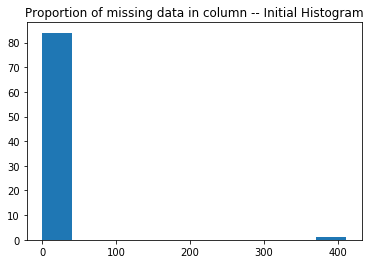

```python
plt.title("Proportion of missing data in column -- Initial Histogram")
plt.hist(df_missing_proportion)
```

```python
print("Disproportionate NaN/data ratio -- above 5% :")
df_missing_proportion[df_missing_proportion.sort_values(ascending=False)>0.05].sort_values(ascending=False)
```

```
Disproportionate NaN/data ratio -- above 5% :
```

```
TITEL_KZ                 411.602315
AGER_TYP                   3.339418
KK_KUNDENTYP               1.906702
KBA05_BAUMAX               1.149090
GEBURTSJAHR                0.786361
ALTER_HH                   0.534065
REGIOTYP                   0.215594
KKK                        0.215594
W_KEIT_KIND_HH             0.199114
KBA05_ANTG4                0.175913
MOBI_REGIO                 0.175913
KBA05_ANTG1                0.175913
KBA05_ANTG2                0.175913
KBA05_ANTG3                0.175913
KBA05_GBZ                  0.175913
PLZ8_ANTG1                 0.150399
PLZ8_GBZ                   0.150399
PLZ8_HHZ                   0.150399
PLZ8_BAUMAX                0.150399
PLZ8_ANTG4                 0.150399
PLZ8_ANTG3                 0.150399
PLZ8_ANTG2                 0.150399
SHOPPER_TYP                0.142554
VERS_TYP                   0.142554
HEALTH_TYP                 0.142554
NATIONALITAET_KZ           0.138350
PRAEGENDE_JUGENDJAHRE      0.138130
KBA13_ANZAHL_PKW           0.134705
ANZ_HAUSHALTE_AKTIV        0.125833
CAMEO_DEUG_2015            0.125465
CAMEO_INTL_2015            0.125465
CAMEO_DEU_2015             0.125465
LP_LEBENSPHASE_FEIN        0.123026
ARBEIT                     0.122662
RELAT_AB                   0.122662
ORTSGR_KLS9                0.122520
ANZ_HH_TITEL               0.122144
LP_LEBENSPHASE_GROB        0.118712
EWDICHTE                   0.117545
INNENSTADT                 0.117545
BALLRAUM                   0.117545
GEBAEUDETYP_RASTER         0.116726
WOHNLAGE                   0.116716
MIN_GEBAEUDEJAHR           0.116716
OST_WEST_KZ                0.116716
GEBAEUDETYP                0.116716
LP_FAMILIE_GROB            0.095635
LP_FAMILIE_FEIN            0.095635
KONSUMNAEHE                0.090509
SOHO_KZ                    0.089883
WOHNDAUER_2008             0.089883
ANZ_PERSONEN               0.089883
ANZ_TITEL                  0.089883
dtype: float64
```

### Features with HUGE amount of missing data proportion are considered outliers:

(top 6 - in %):

- TITEL_KZ 41160.231481
- AGER_TYP 333.941805
- KK_KUNDENTYP 190.670202
- KBA05_BAUMAX 114.908958
- GEBURTSJAHR 78.636128
- ALTER_HH 53.406466

# Investigate patterns in the amount of missing data in each column.

Features with high amount of missing data can't reflect the actual distribution of data.

```
After dropping columns with HIGHEST proportion of missing data:
```

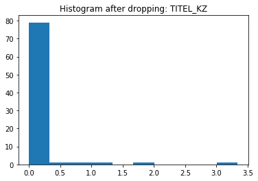

```python
# Remove the outlier columns from the dataset. (You'll perform other data
# engineering tasks such as re-encoding and imputation later.)

#DROP first top outlier contributor, and see
azdias.drop(['TITEL_KZ'],axis=1,inplace=True)

#after cleaning columns with huge missing data
print("After dropping columns with HIGHEST proportion of missing data:")
df_missing_proportion = azdias.isna().sum()/azdias.count()
df_missing_proportion.sort_values(ascending=False)

#display histogram
plt.title("Histogram after dropping: TITEL_KZ")
plt.hist(df_missing_proportion)
plt.show()
```

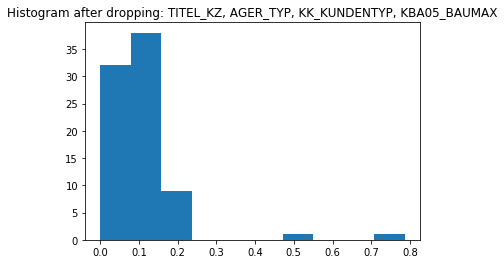

```python
#dropping more outliers
azdias.drop(['AGER_TYP','KK_KUNDENTYP','KBA05_BAUMAX'],axis=1,inplace=True)

#new proportion is calculated
df_missing_proportion = azdias.isna().sum()/azdias.count()
df_missing_proportion.sort_values(ascending=False)

#display histogram
plt.title("Histogram after dropping: TITEL_KZ, AGER_TYP, KK_KUNDENTYP, KBA05_BAUMAX")
plt.hist(df_missing_proportion)
plt.show()
```

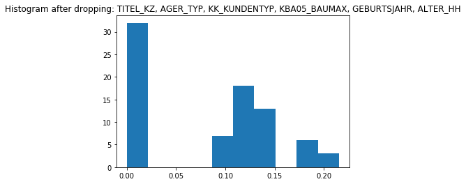

```python
#dropping more outlier columns
azdias.drop(['GEBURTSJAHR','ALTER_HH'],axis=1,inplace=True)

#new proportion is calculated
df_missing_proportion = azdias.isna().sum()/azdias.count()
df_missing_proportion.sort_values(ascending=False)

#new histogram
plt.title("Histogram after dropping: TITEL_KZ, AGER_TYP, KK_KUNDENTYP, KBA05_BAUMAX, GEBURTSJAHR, ALTER_HH")
plt.hist(df_missing_proportion)
plt.show()
```

#### Discussion 1.1.2: Assess Missing Data in Each Column

The following columns & its proportion (NaN to data) are outliers and are dropped:

- TITEL_KZ 411.602315
- AGER_TYP 3.339418
- KK_KUNDENTYP 1.906702
- KBA05_BAUMAX 1.149090
- GEBURTSJAHR 0.786361
- ALTER_HH 0.534065

#### Step 1.1.3: Assess Missing Data in Each Row

Now, you'll perform a similar assessment for the rows of the dataset. How much data is missing in each row? As with the columns, you should see some groups of points that have a very different numbers of missing values. Divide the data into two subsets: one for data points that are above some threshold for missing values, and a second subset for points below that threshold.

In order to know what to do with the outlier rows, we should see if the distribution of data values on columns that are not missing data (or are missing very little data) are similar or different between the two groups. Select at least five of these columns and compare the distribution of values.

- You can use seaborn's [`countplot()`](https://seaborn.pydata.org/generated/seaborn.countplot.html) function to create a bar chart of code frequencies and matplotlib's [`subplot()`](https://matplotlib.org/api/_as_gen/matplotlib.pyplot.subplot.html) function to put bar charts for the two subplots side by side.
- To reduce repeated code, you might want to write a function that can perform this comparison, taking as one of its arguments a column to be compared.

Depending on what you observe in your comparison, this will have implications on how you approach your conclusions later in the analysis. If the distributions of non-missing features look similar between the data with many missing values and the data with few or no missing values, then we could argue that simply dropping those points from the analysis won't present a major issue. On the other hand, if the data with many missing values looks very different from the data with few or no missing values, then we should make a note on those data as special. We'll revisit these data later on. **Either way, you should continue your analysis for now using just the subset of the data with few or no missing values.**

```python
# How much data is missing in each row of the dataset?
print("Missing data in rows:")
df_missing_rows = azdias.isna().sum(axis=1)
df_missing_rows.sort_values(ascending=False)
```

```
Missing data in rows:
```

```
643174    49
732775    49
472919    48
183108    47
139316    47
691141    47
691142    47
691171    47
691183    47
139332    47
691197    47
139323    47
691212    47
691122    47
139267    47
```

[output cut: 47 more lines]

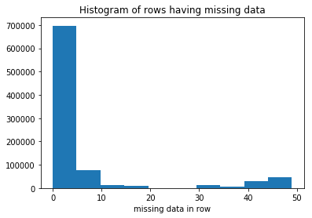

```python
plt.title("Histogram of rows having missing data")
plt.hist(df_missing_rows)
plt.xlabel("missing data in row")
plt.show()
```

#### Looks like the cut-off is above 25 and below 25

```python
# Write code to divide the data into two subsets based on the number of missing
# values in each row.

threshold = 25
#missing values > 25
az_gt_25 = azdias[df_missing_rows > threshold].copy()

#missing values <= 25
az_lte_25 = azdias[df_missing_rows <= threshold].copy()

print(f"amount of rows with missing value > 25: {len(az_gt_25)}")
print(f"amount of rows with missing value <= 25: {len(az_lte_25)}")
print(f"total rows: {len(az_gt_25) + len(az_lte_25)}")
```

```
amount of rows with missing value > 25: 93260
amount of rows with missing value <= 25: 797961
total rows: 891221
```

```python
# Compare the distribution of values for at least five columns where there are
# no or few missing values, between the two subsets.

#plot side by side
def plot_side2side(col,suptitle,title_left,title_right,data_left,data_right):
    plt.figure()
    fig, (ax1, ax2) = plt.subplots(1,2,sharey=True)
    sns.countplot(x=col, data=data_left,ax=ax1)
    ax1.set_title(title_left)
    sns.countplot(x=col, data=data_right,ax=ax2)
    ax2.set_title(title_right)
    fig.suptitle(suptitle)
    plt.setp(ax1.xaxis.get_majorticklabels(), rotation=45)
    plt.setp(ax2.xaxis.get_majorticklabels(), rotation=45)
    plt.show()
```

#### Selected Features for side-by-side countplot comparison

```
  Feature             Missing Data Proportion
```

- LP_STATUS_GROB 0.005476
- ALTERSKATEGORIE_GROB 0.003243
- ZABEOTYP 0.000000
- SEMIO_FAM 0.000000
- GREEN_AVANTGARDE 0.000000
- FINANZTYP 0.000000

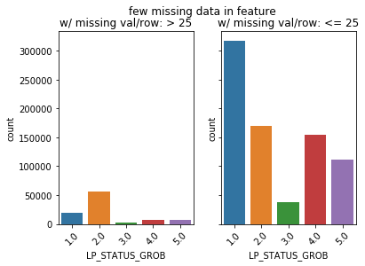

```python
plot_side2side('LP_STATUS_GROB','few missing data in feature',"w/ missing val/row: > 25","w/ missing val/row: <= 25",az_gt_25,az_lte_25)
```

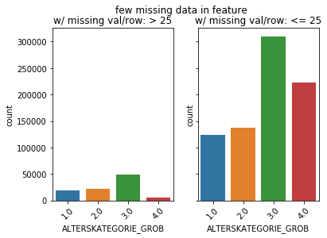

```python
plot_side2side('ALTERSKATEGORIE_GROB','few missing data in feature',"w/ missing val/row: > 25","w/ missing val/row: <= 25",az_gt_25,az_lte_25)
```

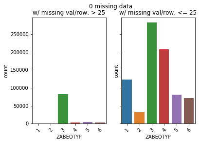

```python
plot_side2side('ZABEOTYP','0 missing data',"w/ missing val/row: > 25","w/ missing val/row: <= 25",az_gt_25,az_lte_25)
```

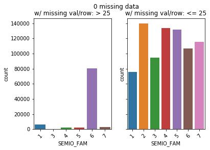

```python
plot_side2side('SEMIO_FAM','0 missing data',"w/ missing val/row: > 25","w/ missing val/row: <= 25",az_gt_25,az_lte_25)
```

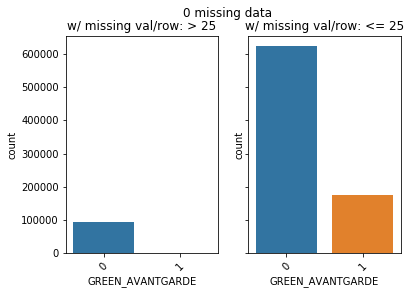

```python
plot_side2side('GREEN_AVANTGARDE','0 missing data',"w/ missing val/row: > 25","w/ missing val/row: <= 25",az_gt_25,az_lte_25)
```

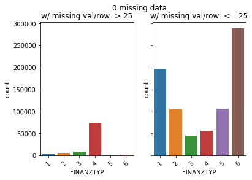

```python
plot_side2side('FINANZTYP','0 missing data',"w/ missing val/row: > 25","w/ missing val/row: <= 25",az_gt_25,az_lte_25)
```

### Step 1.2: Select and Re-Encode Features

Checking for missing data isn't the only way in which you can prepare a dataset for analysis. Since the unsupervised learning techniques to be used will only work on data that is encoded numerically, you need to make a few encoding changes or additional assumptions to be able to make progress. In addition, while almost all of the values in the dataset are encoded using numbers, not all of them represent numeric values. Check the third column of the feature summary (`feat_info`) for a summary of types of measurement.

- For numeric and interval data, these features can be kept without changes.
- Most of the variables in the dataset are ordinal in nature. While ordinal values may technically be non-linear in spacing, make the simplifying assumption that the ordinal variables can be treated as being interval in nature (that is, kept without any changes).
- Special handling may be necessary for the remaining two variable types: categorical, and 'mixed'.

In the first two parts of this sub-step, you will perform an investigation of the categorical and mixed-type features and make a decision on each of them, whether you will keep, drop, or re-encode each. Then, in the last part, you will create a new data frame with only the selected and engineered columns.

Data wrangling is often the trickiest part of the data analysis process, and there's a lot of it to be done here. But stick with it: once you're done with this step, you'll be ready to get to the machine learning parts of the project!

```python
# How many features are there of each data type?
feat[['type','attribute']].groupby('type').count()
```

| type | attribute |
| --- | --- |
| categorical | 21 |
| interval | 1 |
| mixed | 7 |
| numeric | 7 |
| ordinal | 49 |

#### Step 1.2.1: Re-Encode Categorical Features

For categorical data, you would ordinarily need to encode the levels as dummy variables. Depending on the number of categories, perform one of the following:

- For binary (two-level) categoricals that take numeric values, you can keep them without needing to do anything.
- There is one binary variable that takes on non-numeric values. For this one, you need to re-encode the values as numbers or create a dummy variable.
- For multi-level categoricals (three or more values), you can choose to encode the values using multiple dummy variables (e.g. via [OneHotEncoder](http://scikit-learn.org/stable/modules/generated/sklearn.preprocessing.OneHotEncoder.html)), or (to keep things straightforward) just drop them from the analysis. As always, document your choices in the Discussion section.

```python
#which feature are categoricals?
categorical_feat = feat[['type','attribute']][feat['type'] == 'categorical']
print("Categorical features:")
categorical_feat
```

```
Categorical features:
```

|  | type | attribute |
| --- | --- | --- |
| 0 | categorical | AGER_TYP |
| 2 | categorical | ANREDE_KZ |
| 3 | categorical | CJT_GESAMTTYP |
| 10 | categorical | FINANZTYP |
| 12 | categorical | GFK_URLAUBERTYP |
| 13 | categorical | GREEN_AVANTGARDE |
| 17 | categorical | LP_FAMILIE_FEIN |
| 18 | categorical | LP_FAMILIE_GROB |
| 19 | categorical | LP_STATUS_FEIN |
| 20 | categorical | LP_STATUS_GROB |
| 21 | categorical | NATIONALITAET_KZ |
| 38 | categorical | SHOPPER_TYP |
| 39 | categorical | SOHO_KZ |
| 40 | categorical | TITEL_KZ |
| 41 | categorical | VERS_TYP |
| 42 | categorical | ZABEOTYP |
| 47 | categorical | KK_KUNDENTYP |
| 52 | categorical | GEBAEUDETYP |
| 55 | categorical | OST_WEST_KZ |
| 57 | categorical | CAMEO_DEUG_2015 |
| 58 | categorical | CAMEO_DEU_2015 |

```python
categorical_lists = []
for i in categorical_feat['attribute']:
    if i in az_lte_25.columns:
            categorical_lists.append(i)

#data with missing rows <= 25 & belongs to these categorical features
print("Categorical Features in the datasets that i use (with <= 25 missing data per row):")
az_lte_25[categorical_lists].columns
```

```
Categorical Features in the datasets that i use (with <= 25 missing data per row):
```

```
Index(['ANREDE_KZ', 'CJT_GESAMTTYP', 'FINANZTYP', 'GFK_URLAUBERTYP',
       'GREEN_AVANTGARDE', 'LP_FAMILIE_FEIN', 'LP_FAMILIE_GROB',
       'LP_STATUS_FEIN', 'LP_STATUS_GROB', 'NATIONALITAET_KZ', 'SHOPPER_TYP',
       'SOHO_KZ', 'VERS_TYP', 'ZABEOTYP', 'GEBAEUDETYP', 'OST_WEST_KZ',
       'CAMEO_DEUG_2015', 'CAMEO_DEU_2015'],
      dtype='object')
```

```python
#non-numerical features
print("Non-Numerical Categories:")
az_lte_25.select_dtypes(include=[object]).head()
```

```
Non-Numerical Categories:
```

|  | OST_WEST_KZ | CAMEO_DEUG_2015 | CAMEO_DEU_2015 | CAMEO_INTL_2015 |
| --- | --- | --- | --- | --- |
| 1 | W | 8 | 8A | 51 |
| 2 | W | 4 | 4C | 24 |
| 3 | W | 2 | 2A | 12 |
| 4 | W | 6 | 6B | 43 |
| 5 | W | 8 | 8C | 54 |

```python
#one mixed type which initially i thought belongs to categorical
feat[['type','attribute']][feat['attribute']=='CAMEO_INTL_2015']
```

|  | type | attribute |
| --- | --- | --- |
| 59 | mixed | CAMEO_INTL_2015 |

```python
# Assess categorical variables: which are binary, which are multi-level, and
# which one needs to be re-encoded?
bin_feats = ['ANREDE_KZ','GREEN_AVANTGARDE','SOHO_KZ','VERS_TYP']
bin_non_numerics = ['OST_WEST_KZ']
mult_categoricals = ['CJT_GESAMTTYP','FINANZTYP','GFK_URLAUBERTYP','LP_FAMILIE_FEIN',
                     'LP_FAMILIE_GROB','LP_STATUS_GROB','NATIONALITAET_KZ','SHOPPER_TYP',
                    'ZABEOTYP','GEBAEUDETYP','CAMEO_DEUG_2015','CAMEO_DEU_2015']

print(f"Binary features - numericals = {bin_feats}")
print(f"Binary features with non-numeric values = {bin_non_numerics}")
print(f"Features with multi-level categoricals = {mult_categoricals}")
```

```
Binary features - numericals = ['ANREDE_KZ', 'GREEN_AVANTGARDE', 'SOHO_KZ', 'VERS_TYP']
Binary features with non-numeric values = ['OST_WEST_KZ']
Features with multi-level categoricals = ['CJT_GESAMTTYP', 'FINANZTYP', 'GFK_URLAUBERTYP', 'LP_FAMILIE_FEIN', 'LP_FAMILIE_GROB', 'LP_STATUS_GROB', 'NATIONALITAET_KZ', 'SHOPPER_TYP', 'ZABEOTYP', 'GEBAEUDETYP', 'CAMEO_DEUG_2015', 'CAMEO_DEU_2015']
```

```python
# Re-encode categorical variable(s) to be kept in the analysis. >> dropped
# dropping multiple level categorical features to reduce complexity
az_lte_25.drop(mult_categoricals,axis=1,inplace=True)

#re-encode binary categorical
from sklearn.preprocessing import LabelEncoder
le = LabelEncoder()
az_lte_25['OST_WEST_KZ'] = le.fit_transform(az_lte_25['OST_WEST_KZ'])
```

```python
az_lte_25['OST_WEST_KZ'].unique()
```

```
array([1, 0])
```

```python
az_lte_25.head()
```

|  | ALTERSKATEGORIE_GROB | ANREDE_KZ | FINANZ_MINIMALIST | FINANZ_SPARER | FINANZ_VORSORGER | FINANZ_ANLEGER | FINANZ_UNAUFFAELLIGER | FINANZ_HAUSBAUER | GREEN_AVANTGARDE | HEALTH_TYP | ... | PLZ8_ANTG1 | PLZ8_ANTG2 | PLZ8_ANTG3 | PLZ8_ANTG4 | PLZ8_BAUMAX | PLZ8_HHZ | PLZ8_GBZ | ARBEIT | ORTSGR_KLS9 | RELAT_AB |
| --- | --- | --- | --- | --- | --- | --- | --- | --- | --- | --- | --- | --- | --- | --- | --- | --- | --- | --- | --- | --- | --- |
| 1 | 1.0 | 2 | 1 | 5 | 2 | 5 | 4 | 5 | 0 | 3.0 | ... | 2.0 | 3.0 | 2.0 | 1.0 | 1.0 | 5.0 | 4.0 | 3.0 | 5.0 | 4.0 |
| 2 | 3.0 | 2 | 1 | 4 | 1 | 2 | 3 | 5 | 1 | 3.0 | ... | 3.0 | 3.0 | 1.0 | 0.0 | 1.0 | 4.0 | 4.0 | 3.0 | 5.0 | 2.0 |
| 3 | 4.0 | 2 | 4 | 2 | 5 | 2 | 1 | 2 | 0 | 2.0 | ... | 2.0 | 2.0 | 2.0 | 0.0 | 1.0 | 3.0 | 4.0 | 2.0 | 3.0 | 3.0 |
| 4 | 3.0 | 1 | 4 | 3 | 4 | 1 | 3 | 2 | 0 | 3.0 | ... | 2.0 | 4.0 | 2.0 | 1.0 | 2.0 | 3.0 | 3.0 | 4.0 | 6.0 | 5.0 |
| 5 | 1.0 | 2 | 3 | 1 | 5 | 2 | 2 | 5 | 0 | 3.0 | ... | 2.0 | 3.0 | 1.0 | 1.0 | 1.0 | 5.0 | 5.0 | 2.0 | 3.0 | 3.0 |

5 rows × 67 columns

#### Discussion 1.2.1: Re-Encode Categorical Features

(Double-click this cell and replace this text with your own text, reporting your findings and decisions regarding categorical features. Which ones did you keep, which did you drop, and what engineering steps did you perform?)

- Binary categorical features are kept: 'ANREDE_KZ', 'GREEN_AVANTGARDE', 'SOHO_KZ', 'VERS_TYP'
- Multi-level categoricals are dropped to keep it simple & straightforward: 'CJT_GESAMTTYP', 'FINANZTYP', 'GFK_URLAUBERTYP', 'LP_FAMILIE_FEIN', 'LP_FAMILIE_GROB', 'LP_STATUS_GROB', 'NATIONALITAET_KZ', 'SHOPPER_TYP', 'ZABEOTYP', 'GEBAEUDETYP', 'CAMEO_DEUG_2015', 'CAMEO_DEU_2015'
- Binary feature with non-numerical values is re-encoded with labelencoder = 'OST_WEST_KZ'

#### Step 1.2.2: Engineer Mixed-Type Features

There are a handful of features that are marked as "mixed" in the feature summary that require special treatment in order to be included in the analysis. There are two in particular that deserve attention; the handling of the rest are up to your own choices:

- "PRAEGENDE_JUGENDJAHRE" combines information on three dimensions: generation by decade, movement (mainstream vs. avantgarde), and nation (east vs. west). While there aren't enough levels to disentangle east from west, you should create two new variables to capture the other two dimensions: an interval-type variable for decade, and a binary variable for movement.
- "CAMEO_INTL_2015" combines information on two axes: wealth and life stage. Break up the two-digit codes by their 'tens'-place and 'ones'-place digits into two new ordinal variables (which, for the purposes of this project, is equivalent to just treating them as their raw numeric values).
- If you decide to keep or engineer new features around the other mixed-type features, make sure you note your steps in the Discussion section.

Be sure to check `Data_Dictionary.md` for the details needed to finish these tasks.

```python
# Investigate "PRAEGENDE_JUGENDJAHRE" and engineer two new variables.

#new variables:
# PJ_DECADE:
# - 1: 40s
# - 2: 50s
# - 3: 60s
# - 4: 70s
# - 5: 80s
# - 6: 90s
def pj_decade(d):
    if 1.0 <= d['PRAEGENDE_JUGENDJAHRE'] <= 2.0:
        return 1
    elif 3.0 <= d['PRAEGENDE_JUGENDJAHRE'] <= 4.0:
        return 2
    elif 5.0 <= d['PRAEGENDE_JUGENDJAHRE'] <= 7.0:
        return 3
    elif 8.0 <= d['PRAEGENDE_JUGENDJAHRE'] <= 9.0:
        return 4
    elif 10.0 <= d['PRAEGENDE_JUGENDJAHRE'] <= 13.0:
        return 5
    elif 14.0 <= d['PRAEGENDE_JUGENDJAHRE'] <= 15.0:
        return 6

# PJ_MOVEMENT:
# - 0: E
# - 1: W
def pj_movement(d):
    if d['PRAEGENDE_JUGENDJAHRE'] == 6.0:
        return 1
    elif d['PRAEGENDE_JUGENDJAHRE'] == 7.0:
        return 0
    elif d['PRAEGENDE_JUGENDJAHRE'] == 10.0:
        return 1
    elif d['PRAEGENDE_JUGENDJAHRE'] == 11.0:
        return 1
    elif d['PRAEGENDE_JUGENDJAHRE'] == 12.0:
        return 0
    elif d['PRAEGENDE_JUGENDJAHRE'] == 13.0:
        return 0
    else:
        return np.nan

az_lte_25['PJ_MOVEMENT'] = az_lte_25.apply(pj_movement, axis=1)
az_lte_25['PJ_DECADE'] =az_lte_25.apply(pj_decade, axis=1)
```

```python
# Investigate "CAMEO_INTL_2015" and engineer two new variables.
#az_lte_25['CAMEO_INTL_2015'].head()

#new variables:
#CI2015_TENS
def ci2015_tens(d):
    try:
        return int(int(d['CAMEO_INTL_2015'])/10)
    except ValueError:
        return np.nan

#CI2015_ONES
def ci2015_ones(d):
    try:
        return int(d['CAMEO_INTL_2015']) % 10
    except ValueError:
        return np.nan

az_lte_25['CI2015_TENS'] = az_lte_25.apply(ci2015_tens,axis=1)
az_lte_25['CI2015_ONES'] = az_lte_25.apply(ci2015_ones,axis=1)
```

```python
mixed_features = feat[['type','attribute']][feat['type'] == 'mixed']

mixed_feat_lists = []
for i in mixed_features['attribute']:
    if i in az_lte_25.columns:
            mixed_feat_lists.append(i)

print("Mixed features in my dataset:")
az_lte_25[mixed_feat_lists].columns
```

```
Mixed features in my dataset:
```

```
Index(['LP_LEBENSPHASE_FEIN', 'LP_LEBENSPHASE_GROB', 'PRAEGENDE_JUGENDJAHRE',
       'WOHNLAGE', 'CAMEO_INTL_2015', 'PLZ8_BAUMAX'],
      dtype='object')
```

```python
print(f"Mixed features in original data: {mixed_features}")
```

```
Mixed features in original data:      type              attribute
15  mixed    LP_LEBENSPHASE_FEIN
16  mixed    LP_LEBENSPHASE_GROB
22  mixed  PRAEGENDE_JUGENDJAHRE
56  mixed               WOHNLAGE
59  mixed        CAMEO_INTL_2015
64  mixed           KBA05_BAUMAX
79  mixed            PLZ8_BAUMAX
```

#### Discussion 1.2.2: Engineer Mixed-Type Features

(Double-click this cell and replace this text with your own text, reporting your findings and decisions regarding mixed-value features. Which ones did you keep, which did you drop, and what engineering steps did you perform?)

- Mixed-Value Features that i keep: LP_LEBENSPHASE_FEIN, LP_LEBENSPHASE_GROB, WOHNLAGE, PLZ8_BAUMAX
- Mixed-Value Features that i re-engineered into new features: PRAEGENDE_JUGENDJAHRE, CAMEO_INTL_2015
- Mixed-Value Features that i dropped: KBA05_BAUMAX (reason: too much NaN in columns)

#### Step 1.2.3: Complete Feature Selection

In order to finish this step up, you need to make sure that your data frame now only has the columns that you want to keep. To summarize, the dataframe should consist of the following:

- All numeric, interval, and ordinal type columns from the original dataset.
- Binary categorical features (all numerically-encoded).
- Engineered features from other multi-level categorical features and mixed features.

Make sure that for any new columns that you have engineered, that you've excluded the original columns from the final dataset. Otherwise, their values will interfere with the analysis later on the project. For example, you should not keep "PRAEGENDE_JUGENDJAHRE", since its values won't be useful for the algorithm: only the values derived from it in the engineered features you created should be retained. As a reminder, your data should only be from **the subset with few or no missing values**.

```python
# If there are other re-engineering tasks you need to perform, make sure you
# take care of them here. (Dealing with missing data will come in step 2.1.)
print("Dropping original: PRAEGENDE_JUGENDJAHRE, CAMEO_INTL_2015 and retain the engineered features: PJ_MOVEMENT, PJ_DECADE, CI2015_TENS, CI2015_ONES")
az_lte_25.drop(['PRAEGENDE_JUGENDJAHRE','CAMEO_INTL_2015'],axis=1,inplace=True)
```

```
Dropping original: PRAEGENDE_JUGENDJAHRE, CAMEO_INTL_2015 and retain the engineered features: PJ_MOVEMENT, PJ_DECADE, CI2015_TENS, CI2015_ONES
```

```python
#no more non-numerics
print(f"Non-numerics: {az_lte_25.select_dtypes(include=[object])}")

az_lte_25.head()
```

[output not shown]

|  | ALTERSKATEGORIE_GROB | ANREDE_KZ | FINANZ_MINIMALIST | FINANZ_SPARER | FINANZ_VORSORGER | FINANZ_ANLEGER | FINANZ_UNAUFFAELLIGER | FINANZ_HAUSBAUER | GREEN_AVANTGARDE | HEALTH_TYP | ... | PLZ8_BAUMAX | PLZ8_HHZ | PLZ8_GBZ | ARBEIT | ORTSGR_KLS9 | RELAT_AB | PJ_MOVEMENT | PJ_DECADE | CI2015_TENS | CI2015_ONES |
| --- | --- | --- | --- | --- | --- | --- | --- | --- | --- | --- | --- | --- | --- | --- | --- | --- | --- | --- | --- | --- | --- |
| 1 | 1.0 | 2 | 1 | 5 | 2 | 5 | 4 | 5 | 0 | 3.0 | ... | 1.0 | 5.0 | 4.0 | 3.0 | 5.0 | 4.0 | NaN | 6.0 | 5.0 | 1.0 |
| 2 | 3.0 | 2 | 1 | 4 | 1 | 2 | 3 | 5 | 1 | 3.0 | ... | 1.0 | 4.0 | 4.0 | 3.0 | 5.0 | 2.0 | NaN | 6.0 | 2.0 | 4.0 |
| 3 | 4.0 | 2 | 4 | 2 | 5 | 2 | 1 | 2 | 0 | 2.0 | ... | 1.0 | 3.0 | 4.0 | 2.0 | 3.0 | 3.0 | NaN | 4.0 | 1.0 | 2.0 |
| 4 | 3.0 | 1 | 4 | 3 | 4 | 1 | 3 | 2 | 0 | 3.0 | ... | 2.0 | 3.0 | 3.0 | 4.0 | 6.0 | 5.0 | NaN | 4.0 | 4.0 | 3.0 |
| 5 | 1.0 | 2 | 3 | 1 | 5 | 2 | 2 | 5 | 0 | 3.0 | ... | 1.0 | 5.0 | 5.0 | 2.0 | 3.0 | 3.0 | NaN | 2.0 | 5.0 | 4.0 |

5 rows × 69 columns

```python
# Do whatever you need to in order to ensure that the dataframe only contains
# the columns that should be passed to the algorithm functions.
```

### Step 1.3: Create a Cleaning Function

Even though you've finished cleaning up the general population demographics data, it's important to look ahead to the future and realize that you'll need to perform the same cleaning steps on the customer demographics data. In this substep, complete the function below to execute the main feature selection, encoding, and re-engineering steps you performed above. Then, when it comes to looking at the customer data in Step 3, you can just run this function on that DataFrame to get the trimmed dataset in a single step.

```python
from sklearn.preprocessing import LabelEncoder

#CI2015_TENS
def ci2015_tens(d):
    try:
        return int(int(d['CAMEO_INTL_2015'])/10)
    except ValueError:
        return np.nan

#CI2015_ONES
def ci2015_ones(d):
    try:
        return int(d['CAMEO_INTL_2015']) % 10
    except ValueError:
        return np.nan

# PJ_DECADE:
# - 1: 40s
# - 2: 50s
# - 3: 60s
# - 4: 70s
# - 5: 80s
# - 6: 90s
def pj_decade(d):
    if 1.0 <= d['PRAEGENDE_JUGENDJAHRE'] <= 2.0:
        return 1
    elif 3.0 <= d['PRAEGENDE_JUGENDJAHRE'] <= 4.0:
        return 2
    elif 5.0 <= d['PRAEGENDE_JUGENDJAHRE'] <= 7.0:
        return 3
    elif 8.0 <= d['PRAEGENDE_JUGENDJAHRE'] <= 9.0:
        return 4
    elif 10.0 <= d['PRAEGENDE_JUGENDJAHRE'] <= 13.0:
        return 5
    elif 14.0 <= d['PRAEGENDE_JUGENDJAHRE'] <= 15.0:
        return 6

# PJ_MOVEMENT:
# - 0: E
# - 1: W
def pj_movement(d):
    if d['PRAEGENDE_JUGENDJAHRE'] == 6.0:
        return 1
    elif d['PRAEGENDE_JUGENDJAHRE'] == 7.0:
        return 0
    elif d['PRAEGENDE_JUGENDJAHRE'] == 10.0:
        return 1
    elif d['PRAEGENDE_JUGENDJAHRE'] == 11.0:
        return 1
    elif d['PRAEGENDE_JUGENDJAHRE'] == 12.0:
        return 0
    elif d['PRAEGENDE_JUGENDJAHRE'] == 13.0:
        return 0
    else:
        return np.nan

def convert_missings_to_nan(df,feat):
    missing=feat['missing_or_unknown'].to_dict()
    attr=feat['attribute'].to_dict()

    for ft in range(len(feat)):
        list_missing_vals = missing[ft].strip('[]').split(',') #in str list e.g. ['-1','0','X']
        attr_name = attr[ft]

        try:
            # if ['-1','0'], treat it as [-1,0] -- (float)
            df[attr_name].replace([int(s) for s in list_missing_vals],np.nan,inplace=True)

        except ValueError:
            # if ['-1','X'] keep it as-is -- (str)

            df[attr_name].replace(list_missing_vals,np.nan,inplace=True)

    return df

def remove_missings(df,cols):
    #remove cols
    df.drop(cols,axis=1,inplace=True)

    #use rows with threshold of missing data in row <= 25
    threshold = 25
    df_missing_rows = df.isna().sum(axis=1)

    return df[df_missing_rows <= threshold].copy()

def reengineer(df,cols,enc):
    #drop multi-level categorical cols
    df.drop(cols,axis=1,inplace=True)

    #re-encode
    le = LabelEncoder()
    df[enc] = le.fit_transform(df[enc])

    #reengineer new features
    df['PJ_MOVEMENT'] = df.apply(pj_movement, axis=1)
    df['PJ_DECADE'] = df.apply(pj_decade, axis=1)
    df['CI2015_TENS'] = df.apply(ci2015_tens,axis=1)
    df['CI2015_ONES'] = df.apply(ci2015_ones,axis=1)

    #drop old features
    df.drop(['PRAEGENDE_JUGENDJAHRE','CAMEO_INTL_2015'],axis=1,inplace=True)

    return df

def clean_data(df):
    """
    Perform feature trimming, re-encoding, and engineering for demographics
    data

    INPUT: Demographics DataFrame
    OUTPUT: Trimmed and cleaned demographics DataFrame
    """

    # Put in code here to execute all main cleaning steps:
    # convert missing value codes into NaNs, ...
    df = convert_missings_to_nan(df,feat)

    # remove selected columns and rows, ...
    df = remove_missings(df,['TITEL_KZ','AGER_TYP','KK_KUNDENTYP','KBA05_BAUMAX','GEBURTSJAHR','ALTER_HH'])

    # select, re-encode, and engineer column values.
    mult_categoricals = ['CJT_GESAMTTYP','FINANZTYP','GFK_URLAUBERTYP','LP_FAMILIE_FEIN',
                     'LP_FAMILIE_GROB','LP_STATUS_GROB','NATIONALITAET_KZ','SHOPPER_TYP',
                    'ZABEOTYP','GEBAEUDETYP','CAMEO_DEUG_2015','CAMEO_DEU_2015']
    bin_enc_col = 'OST_WEST_KZ'
    df = reengineer(df,mult_categoricals,bin_enc_col)

    #impute the rest
    fill_NaN = Imputer(missing_values=np.nan, strategy='mean', axis=1)
    imputed_df = pd.DataFrame(fill_NaN.fit_transform(df))
    imputed_df.columns = df.columns
    imputed_df.index = df.index

    # Return the cleaned dataframe - final.
    return imputed_df
```

## Step 2: Feature Transformation

### Step 2.1: Apply Feature Scaling

Before we apply dimensionality reduction techniques to the data, we need to perform feature scaling so that the principal component vectors are not influenced by the natural differences in scale for features. Starting from this part of the project, you'll want to keep an eye on the [API reference page for sklearn](http://scikit-learn.org/stable/modules/classes.html) to help you navigate to all of the classes and functions that you'll need. In this substep, you'll need to check the following:

- sklearn requires that data not have missing values in order for its estimators to work properly. So, before applying the scaler to your data, make sure that you've cleaned the DataFrame of the remaining missing values. This can be as simple as just removing all data points with missing data, or applying an [Imputer](http://scikit-learn.org/stable/modules/generated/sklearn.preprocessing.Imputer.html) to replace all missing values. You might also try a more complicated procedure where you temporarily remove missing values in order to compute the scaling parameters before re-introducing those missing values and applying imputation. Think about how much missing data you have and what possible effects each approach might have on your analysis, and justify your decision in the discussion section below.
- For the actual scaling function, a [StandardScaler](http://scikit-learn.org/stable/modules/generated/sklearn.preprocessing.StandardScaler.html) instance is suggested, scaling each feature to mean 0 and standard deviation 1.
- For these classes, you can make use of the `.fit_transform()` method to both fit a procedure to the data as well as apply the transformation to the data at the same time. Don't forget to keep the fit sklearn objects handy, since you'll be applying them to the customer demographics data towards the end of the project.

```python
print("Missing data in rows:")
df_missing_rows = az_lte_25.isna().sum(axis=1)
df_missing_rows.sort_values(ascending=False)

print(f"Amount of rows with NO missing data: {len(az_lte_25[df_missing_rows == 0])}")
print(f"Amount of rows with missing data: {len(az_lte_25[df_missing_rows > 0])}")
```

```
Missing data in rows:
Amount of rows with NO missing data: 147796
Amount of rows with missing data: 650165
```

```python
from sklearn.preprocessing import Imputer

# If you've not yet cleaned the dataset of all NaN values, then investigate and
# do that now.

#rows with missing data is high in proportion (although the outliers were removed & sliced), i decide to use imputer instead of dropping them

fill_NaN = Imputer(missing_values=np.nan, strategy='mean', axis=1)
imputed_df = pd.DataFrame(fill_NaN.fit_transform(az_lte_25))
imputed_df.columns = az_lte_25.columns
imputed_df.index = az_lte_25.index
```

```python
imputed_df.describe()
```

|  | ALTERSKATEGORIE_GROB | ANREDE_KZ | FINANZ_MINIMALIST | FINANZ_SPARER | FINANZ_VORSORGER | FINANZ_ANLEGER | FINANZ_UNAUFFAELLIGER | FINANZ_HAUSBAUER | GREEN_AVANTGARDE | HEALTH_TYP | ... | PLZ8_BAUMAX | PLZ8_HHZ | PLZ8_GBZ | ARBEIT | ORTSGR_KLS9 | RELAT_AB | PJ_MOVEMENT | PJ_DECADE | CI2015_TENS | CI2015_ONES |
| --- | --- | --- | --- | --- | --- | --- | --- | --- | --- | --- | --- | --- | --- | --- | --- | --- | --- | --- | --- | --- | --- |
| count | 797961.000000 | 797961.000000 | 797961.000000 | 797961.000000 | 797961.000000 | 797961.000000 | 797961.000000 | 797961.000000 | 797961.000000 | 797961.000000 | ... | 797961.000000 | 797961.000000 | 797961.000000 | 797961.000000 | 797961.000000 | 797961.000000 | 797961.000000 | 797961.000000 | 797961.000000 | 797961.000000 |
| mean | 2.942585 | 1.521475 | 3.058910 | 2.715979 | 3.432915 | 2.840878 | 2.658168 | 3.114269 | 0.219585 | 4.132709 | ... | 3.215926 | 4.836197 | 4.611216 | 3.374424 | 5.486044 | 3.279278 | 32.782843 | 5.774968 | 3.561592 | 3.175466 |
| std | 2.700882 | 0.499539 | 1.377562 | 1.485077 | 1.376892 | 1.472751 | 1.399466 | 1.408068 | 0.413966 | 8.919366 | ... | 7.619087 | 7.270471 | 7.327374 | 3.031857 | 3.536340 | 3.174923 | 17.982136 | 7.685025 | 3.732690 | 3.771570 |
| min | 1.000000 | 1.000000 | 1.000000 | 1.000000 | 1.000000 | 1.000000 | 1.000000 | 1.000000 | 0.000000 | 1.000000 | ... | 1.000000 | 1.000000 | 1.000000 | 1.000000 | 1.000000 | 1.000000 | 0.000000 | 1.000000 | 1.000000 | 1.000000 |
| 25% | 2.000000 | 1.000000 | 2.000000 | 1.000000 | 2.000000 | 1.000000 | 1.000000 | 2.000000 | 0.000000 | 2.000000 | ... | 1.000000 | 3.000000 | 3.000000 | 3.000000 | 4.000000 | 2.000000 | 35.102941 | 3.000000 | 2.000000 | 1.000000 |
| 50% | 3.000000 | 2.000000 | 3.000000 | 3.000000 | 4.000000 | 3.000000 | 2.000000 | 3.000000 | 0.000000 | 2.000000 | ... | 1.000000 | 4.000000 | 3.000000 | 3.000000 | 5.000000 | 3.000000 | 39.500000 | 5.000000 | 4.000000 | 3.000000 |
| 75% | 4.000000 | 2.000000 | 4.000000 | 4.000000 | 5.000000 | 4.000000 | 4.000000 | 4.000000 | 0.000000 | 3.000000 | ... | 3.000000 | 4.000000 | 4.000000 | 4.000000 | 7.000000 | 4.000000 | 43.338235 | 6.000000 | 5.000000 | 4.000000 |
| max | 77.638298 | 2.000000 | 5.000000 | 5.000000 | 5.000000 | 5.000000 | 5.000000 | 5.000000 | 1.000000 | 80.085106 | ... | 89.300000 | 89.300000 | 89.300000 | 72.588235 | 72.588235 | 72.588235 | 89.300000 | 82.888889 | 71.870370 | 71.870370 |

8 rows × 69 columns

```python
az_lte_25.describe()
```

|  | ALTERSKATEGORIE_GROB | ANREDE_KZ | FINANZ_MINIMALIST | FINANZ_SPARER | FINANZ_VORSORGER | FINANZ_ANLEGER | FINANZ_UNAUFFAELLIGER | FINANZ_HAUSBAUER | GREEN_AVANTGARDE | HEALTH_TYP | ... | PLZ8_BAUMAX | PLZ8_HHZ | PLZ8_GBZ | ARBEIT | ORTSGR_KLS9 | RELAT_AB | PJ_MOVEMENT | PJ_DECADE | CI2015_TENS | CI2015_ONES |
| --- | --- | --- | --- | --- | --- | --- | --- | --- | --- | --- | --- | --- | --- | --- | --- | --- | --- | --- | --- | --- | --- |
| count | 795160.000000 | 797961.000000 | 797961.000000 | 797961.000000 | 797961.000000 | 797961.000000 | 797961.000000 | 797961.000000 | 797961.000000 | 761281.000000 | ... | 774706.000000 | 774706.000000 | 774706.000000 | 793734.000000 | 793835.000000 | 793734.000000 | 181423.000000 | 769252.000000 | 791840.000000 | 791840.000000 |
| mean | 2.795403 | 1.521475 | 3.058910 | 2.715979 | 3.432915 | 2.840878 | 2.658168 | 3.114269 | 0.219585 | 2.199036 | ... | 1.943913 | 3.612821 | 3.381087 | 3.166730 | 5.293469 | 3.071077 | 0.811380 | 4.331984 | 3.262134 | 2.873022 |
| std | 1.018420 | 0.499539 | 1.377562 | 1.485077 | 1.376892 | 1.472751 | 1.399466 | 1.408068 | 0.413966 | 0.755168 | ... | 1.459654 | 0.973967 | 1.111598 | 0.999059 | 2.303347 | 1.360533 | 0.391208 | 1.457424 | 1.464494 | 1.484775 |
| min | 1.000000 | 1.000000 | 1.000000 | 1.000000 | 1.000000 | 1.000000 | 1.000000 | 1.000000 | 0.000000 | 1.000000 | ... | 1.000000 | 1.000000 | 1.000000 | 1.000000 | 1.000000 | 1.000000 | 0.000000 | 1.000000 | 1.000000 | 1.000000 |
| 25% | 2.000000 | 1.000000 | 2.000000 | 1.000000 | 2.000000 | 1.000000 | 1.000000 | 2.000000 | 0.000000 | 2.000000 | ... | 1.000000 | 3.000000 | 3.000000 | 3.000000 | 4.000000 | 2.000000 | 1.000000 | 3.000000 | 2.000000 | 1.000000 |
| 50% | 3.000000 | 2.000000 | 3.000000 | 3.000000 | 4.000000 | 3.000000 | 2.000000 | 3.000000 | 0.000000 | 2.000000 | ... | 1.000000 | 4.000000 | 3.000000 | 3.000000 | 5.000000 | 3.000000 | 1.000000 | 4.000000 | 4.000000 | 3.000000 |
| 75% | 4.000000 | 2.000000 | 4.000000 | 4.000000 | 5.000000 | 4.000000 | 4.000000 | 4.000000 | 0.000000 | 3.000000 | ... | 3.000000 | 4.000000 | 4.000000 | 4.000000 | 7.000000 | 4.000000 | 1.000000 | 6.000000 | 5.000000 | 4.000000 |
| max | 4.000000 | 2.000000 | 5.000000 | 5.000000 | 5.000000 | 5.000000 | 5.000000 | 5.000000 | 1.000000 | 3.000000 | ... | 5.000000 | 5.000000 | 5.000000 | 5.000000 | 9.000000 | 5.000000 | 1.000000 | 6.000000 | 5.000000 | 5.000000 |

8 rows × 69 columns

```python
from sklearn.preprocessing import StandardScaler

# Apply feature scaling to the general population demographics data.
scaler = StandardScaler()
scaled_df = pd.DataFrame(scaler.fit_transform(imputed_df))
scaled_df.columns = imputed_df.columns
scaled_df.index = imputed_df.index
```

```python
scaled_df.describe()
```

|  | ALTERSKATEGORIE_GROB | ANREDE_KZ | FINANZ_MINIMALIST | FINANZ_SPARER | FINANZ_VORSORGER | FINANZ_ANLEGER | FINANZ_UNAUFFAELLIGER | FINANZ_HAUSBAUER | GREEN_AVANTGARDE | HEALTH_TYP | ... | PLZ8_BAUMAX | PLZ8_HHZ | PLZ8_GBZ | ARBEIT | ORTSGR_KLS9 | RELAT_AB | PJ_MOVEMENT | PJ_DECADE | CI2015_TENS | CI2015_ONES |
| --- | --- | --- | --- | --- | --- | --- | --- | --- | --- | --- | --- | --- | --- | --- | --- | --- | --- | --- | --- | --- | --- |
| count | 7.979610e+05 | 7.979610e+05 | 7.979610e+05 | 7.979610e+05 | 7.979610e+05 | 7.979610e+05 | 7.979610e+05 | 7.979610e+05 | 7.979610e+05 | 7.979610e+05 | ... | 7.979610e+05 | 7.979610e+05 | 7.979610e+05 | 7.979610e+05 | 7.979610e+05 | 7.979610e+05 | 7.979610e+05 | 7.979610e+05 | 7.979610e+05 | 7.979610e+05 |
| mean | -3.946109e-16 | -6.482016e-17 | -9.794927e-19 | 1.301657e-16 | 1.510689e-16 | -7.861320e-17 | 6.868025e-17 | -1.657836e-16 | 7.746007e-17 | 1.359714e-17 | ... | -2.439382e-17 | 2.982066e-16 | 3.679019e-16 | -2.137075e-18 | 5.643659e-17 | 1.170627e-16 | -3.958575e-16 | -6.114528e-16 | -6.518079e-16 | -2.977302e-16 |
| std | 1.000001e+00 | 1.000001e+00 | 1.000001e+00 | 1.000001e+00 | 1.000001e+00 | 1.000001e+00 | 1.000001e+00 | 1.000001e+00 | 1.000001e+00 | 1.000001e+00 | ... | 1.000001e+00 | 1.000001e+00 | 1.000001e+00 | 1.000001e+00 | 1.000001e+00 | 1.000001e+00 | 1.000001e+00 | 1.000001e+00 | 1.000001e+00 | 1.000001e+00 |
| min | -7.192415e-01 | -1.043914e+00 | -1.494605e+00 | -1.155482e+00 | -1.766963e+00 | -1.249960e+00 | -1.184858e+00 | -1.501540e+00 | -5.304422e-01 | -3.512257e-01 | ... | -2.908389e-01 | -5.276411e-01 | -4.928393e-01 | -7.831591e-01 | -1.268557e+00 | -7.179007e-01 | -1.823079e+00 | -6.213344e-01 | -6.862595e-01 | -5.768068e-01 |
| 25% | -3.489917e-01 | -1.043914e+00 | -7.686846e-01 | -1.155482e+00 | -1.040689e+00 | -1.249960e+00 | -1.184858e+00 | -7.913466e-01 | -5.304422e-01 | -2.391101e-01 | ... | -2.908389e-01 | -2.525555e-01 | -2.198901e-01 | -1.234968e-01 | -4.202212e-01 | -4.029322e-01 | 1.290225e-01 | -3.610879e-01 | -4.183560e-01 | -5.768068e-01 |
| 50% | 2.125798e-02 | 9.579333e-01 | -4.276408e-02 | 1.912504e-01 | 4.118594e-01 | 1.080440e-01 | -4.702992e-01 | -8.115294e-02 | -5.304422e-01 | -2.391101e-01 | ... | -2.908389e-01 | -1.150128e-01 | -2.198901e-01 | -1.234968e-01 | -1.374428e-01 | -8.796381e-02 | 3.735463e-01 | -1.008413e-01 | 1.174509e-01 | -4.652332e-02 |
| 75% | 3.915077e-01 | 9.579333e-01 | 6.831564e-01 | 8.646166e-01 | 1.138133e+00 | 7.870460e-01 | 9.588178e-01 | 6.290407e-01 | -5.304422e-01 | -1.269944e-01 | ... | -2.834012e-02 | -1.150128e-01 | -8.341543e-02 | 2.063343e-01 | 4.281140e-01 | 2.270046e-01 | 5.869936e-01 | 2.928196e-02 | 3.853544e-01 | 2.186184e-01 |
| max | 2.765607e+01 | 9.579333e-01 | 1.409077e+00 | 1.537983e+00 | 1.138133e+00 | 1.466048e+00 | 1.673376e+00 | 1.339234e+00 | 1.885219e+00 | 8.515454e+00 | ... | 1.129848e+01 | 1.161738e+01 | 1.155787e+01 | 2.282887e+01 | 1.897505e+01 | 2.183013e+01 | 3.142963e+00 | 1.003432e+01 | 1.830016e+01 | 1.821389e+01 |

8 rows × 69 columns

### Discussion 2.1: Apply Feature Scaling

(Double-click this cell and replace this text with your own text, reporting your decisions regarding feature scaling.)

Feature scaling is a common requirement for many machine learning algorithms: they might behave badly if the individual features are not scaled around 0 mean with std deviation of 1.

### Step 2.2: Perform Dimensionality Reduction

On your scaled data, you are now ready to apply dimensionality reduction techniques.

- Use sklearn's [PCA](http://scikit-learn.org/stable/modules/generated/sklearn.decomposition.PCA.html) class to apply principal component analysis on the data, thus finding the vectors of maximal variance in the data. To start, you should not set any parameters (so all components are computed) or set a number of components that is at least half the number of features (so there's enough features to see the general trend in variability).
- Check out the ratio of variance explained by each principal component as well as the cumulative variance explained. Try plotting the cumulative or sequential values using matplotlib's [`plot()`](https://matplotlib.org/api/_as_gen/matplotlib.pyplot.plot.html) function. Based on what you find, select a value for the number of transformed features you'll retain for the clustering part of the project.
- Once you've made a choice for the number of components to keep, make sure you re-fit a PCA instance to perform the decided-on transformation.

```python
from sklearn.decomposition import PCA

# Apply PCA to the data.
pca = PCA()
df_pca = pca.fit_transform(scaled_df)
```

```python
print(pca.explained_variance_ratio_)
```

```
[  1.55048950e-01   1.08949799e-01   9.14611139e-02   6.78199074e-02
   4.98353198e-02   4.68816954e-02   4.01990724e-02   3.15164689e-02
   2.82960802e-02   2.46688409e-02   2.32834632e-02   2.04965715e-02
   1.93842519e-02   1.91902808e-02   1.75742927e-02   1.63384431e-02
   1.48127379e-02   1.44949847e-02   1.43527300e-02   1.36914283e-02
   1.30152026e-02   1.25525351e-02   1.17604585e-02   1.12027996e-02
   1.02653882e-02   9.38322611e-03   8.79493941e-03   8.01753434e-03
   7.37726056e-03   7.03447994e-03   6.66562504e-03   5.88570308e-03
   5.66984074e-03   5.05807281e-03   4.74543317e-03   4.60693027e-03
   4.38254932e-03   4.27418547e-03   4.01227547e-03   3.81693361e-03
   3.71259139e-03   3.55186353e-03   3.07033576e-03   2.69824021e-03
   2.57480321e-03   2.20373578e-03   2.05895952e-03   1.92431657e-03
   1.89440340e-03   1.72964788e-03   1.41358351e-03   1.25685338e-03
   1.16811448e-03   1.05911274e-03   9.50506024e-04   5.38509163e-04
   3.56512422e-04   2.13294292e-04   1.66163744e-04   1.26686090e-04
   8.83367815e-05   8.40652826e-05   6.92811476e-05   6.74163331e-05
   5.32027159e-05   4.48541995e-05   3.87016016e-05   3.76325233e-05
   3.04711835e-05]
```

```python
print(pca.explained_variance_ratio_.cumsum())
```

```
[ 0.15504895  0.26399875  0.35545986  0.42327977  0.47311509  0.51999679
  0.56019586  0.59171233  0.62000841  0.64467725  0.66796071  0.68845728
  0.70784153  0.72703182  0.74460611  0.76094455  0.77575729  0.79025227
  0.804605    0.81829643  0.83131163  0.84386417  0.85562463  0.86682743
  0.87709282  0.88647604  0.89527098  0.90328852  0.91066578  0.91770026
  0.92436588  0.93025158  0.93592143  0.9409795   0.94572493  0.95033186
  0.95471441  0.9589886   0.96300087  0.96681781  0.9705304   0.97408226
  0.9771526   0.97985084  0.98242564  0.98462938  0.98668833  0.98861265
  0.99050705  0.9922367   0.99365029  0.99490714  0.99607525  0.99713437
  0.99808487  0.99862338  0.99897989  0.99919319  0.99935935  0.99948604
  0.99957438  0.99965844  0.99972772  0.99979514  0.99984834  0.99989319
  0.9999319   0.99996953  1.        ]
```

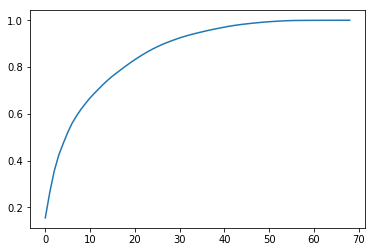

```python
# Investigate the variance accounted for by each principal component.
plt.plot(pca.explained_variance_ratio_.cumsum())
```

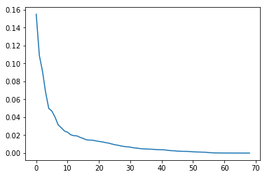

```python
plt.plot(pca.explained_variance_ratio_)
```

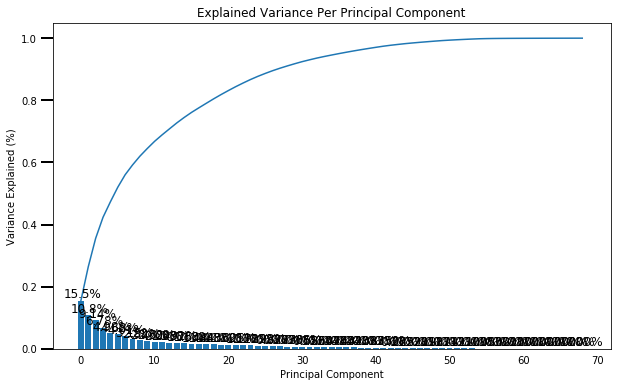

```python
def scree_plot(pca):
    '''
    Creates a scree plot associated with the principal components

    INPUT: pca - the result of instantian of PCA in scikit learn

    OUTPUT:
            None
    '''
    num_components=len(pca.explained_variance_ratio_)
    ind = np.arange(num_components)
    vals = pca.explained_variance_ratio_

    plt.figure(figsize=(10, 6))
    ax = plt.subplot(111)
    cumvals = np.cumsum(vals)
    ax.bar(ind, vals)
    ax.plot(ind, cumvals)
    for i in range(num_components):
        ax.annotate(r"%s%%" % ((str(vals[i]*100)[:4])), (ind[i]+0.2, vals[i]), va="bottom", ha="center", fontsize=12)

    ax.xaxis.set_tick_params(width=0)
    ax.yaxis.set_tick_params(width=2, length=12)

    ax.set_xlabel("Principal Component")
    ax.set_ylabel("Variance Explained (%)")
    plt.title('Explained Variance Per Principal Component')

scree_plot(pca)
```

```python
# Re-apply PCA to the data while selecting for number of components to retain.

pca = PCA(n_components=10)
df_pca = pca.fit_transform(scaled_df)
```

```python
pca.explained_variance_ratio_.cumsum()
```

```
array([ 0.15504895,  0.26399875,  0.35545986,  0.42327974,  0.47311425,
        0.51999526,  0.56019374,  0.59170696,  0.6199987 ,  0.64466242])
```

```python
pca.explained_variance_ratio_
```

```
array([ 0.15504895,  0.1089498 ,  0.09146111,  0.06781989,  0.04983451,
        0.04688101,  0.04019848,  0.03151322,  0.02829174,  0.02466373])
```

```python
pca.explained_variance_ratio_.cumsum()[9]
```

```
0.6446624246397985
```

### Discussion 2.2: Perform Dimensionality Reduction

(Double-click this cell and replace this text with your own text, reporting your findings and decisions regarding dimensionality reduction. How many principal components / transformed features are you retaining for the next step of the analysis?)

10 principal components are chosen (account for 64.4% of variance)

### Step 2.3: Interpret Principal Components

Now that we have our transformed principal components, it's a nice idea to check out the weight of each variable on the first few components to see if they can be interpreted in some fashion.

As a reminder, each principal component is a unit vector that points in the direction of highest variance (after accounting for the variance captured by earlier principal components). The further a weight is from zero, the more the principal component is in the direction of the corresponding feature. If two features have large weights of the same sign (both positive or both negative), then increases in one tend expect to be associated with increases in the other. To contrast, features with different signs can be expected to show a negative correlation: increases in one variable should result in a decrease in the other.

- To investigate the features, you should map each weight to their corresponding feature name, then sort the features according to weight. The most interesting features for each principal component, then, will be those at the beginning and end of the sorted list. Use the data dictionary document to help you understand these most prominent features, their relationships, and what a positive or negative value on the principal component might indicate.
- You should investigate and interpret feature associations from the first three principal components in this substep. To help facilitate this, you should write a function that you can call at any time to print the sorted list of feature weights, for the *i*-th principal component. This might come in handy in the next step of the project, when you interpret the tendencies of the discovered clusters.

```python
def weight_map(pca,df,comp):
    components = pd.DataFrame(np.round(pca.components_, 4), columns = df.keys())
    #sorted_comp = components[:1].T.sort_values(by=0,ascending=False)
    sorted_comp = components.iloc[comp].T.sort_values(ascending=False)
    print(sorted_comp)
    sorted_comp = sorted_comp.T
    #sorted_comp
    fig, ax = plt.subplots(figsize = (14,8))
    sorted_comp.plot(ax=ax, kind='bar')
    title = "component: " + str(comp+1)
    ax.set_title(title)
    ax.set_ylabel("Weights")
```

```
MOBI_REGIO               0.2626
KBA05_GBZ                0.2626
KBA05_ANTG1              0.2619
KBA05_ANTG2              0.2596
KBA05_ANTG4              0.2596
KBA05_ANTG3              0.2587
PLZ8_GBZ                 0.2573
PLZ8_ANTG1               0.2571
PLZ8_HHZ                 0.2532
PLZ8_ANTG4               0.2506
PLZ8_ANTG2               0.2500
PLZ8_ANTG3               0.2483
PLZ8_BAUMAX              0.2443
MIN_GEBAEUDEJAHR         0.2329
KKK                      0.1524
REGIOTYP                 0.1506
CI2015_ONES              0.0602
FINANZ_UNAUFFAELLIGER    0.0595
LP_STATUS_FEIN           0.0548
KONSUMNAEHE              0.0418
FINANZ_MINIMALIST        0.0401
SEMIO_VERT               0.0352
SEMIO_MAT                0.0345
CI2015_TENS              0.0341
INNENSTADT               0.0317
ONLINE_AFFINITAET        0.0290
GEBAEUDETYP_RASTER       0.0279
LP_LEBENSPHASE_FEIN      0.0261
BALLRAUM                 0.0246
PJ_DECADE                0.0203
                          ...
OST_WEST_KZ              0.0099
GREEN_AVANTGARDE         0.0097
SEMIO_REL                0.0094
ANZ_HH_TITEL             0.0093
SEMIO_PFLICHT            0.0055
WOHNLAGE                 0.0052
RETOURTYP_BK_S           0.0033
KBA13_ANZAHL_PKW         0.0028
W_KEIT_KIND_HH           0.0019
SOHO_KZ                  0.0008
ANZ_TITEL                0.0002
SEMIO_KULT              -0.0006
HEALTH_TYP              -0.0030
VERS_TYP                -0.0036
ALTERSKATEGORIE_GROB    -0.0057
ANREDE_KZ               -0.0109
SEMIO_KAEM              -0.0162
SEMIO_SOZ               -0.0173
ARBEIT                  -0.0189
SEMIO_ERL               -0.0192
RELAT_AB                -0.0208
FINANZ_VORSORGER        -0.0218
SEMIO_DOM               -0.0250
ORTSGR_KLS9             -0.0339
ANZ_HAUSHALTE_AKTIV     -0.0344
EWDICHTE                -0.0344
WOHNDAUER_2008          -0.0436
SEMIO_LUST              -0.0437
HH_EINKOMMEN_SCORE      -0.0779
FINANZ_HAUSBAUER        -0.0937
Name: 0, Length: 69, dtype: float64
```

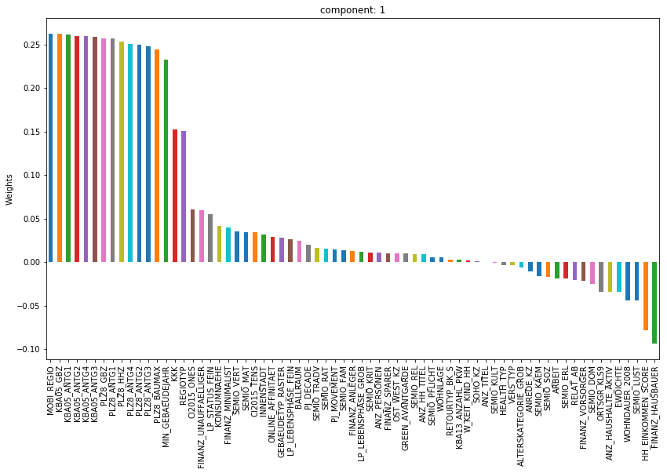

```python
# Map weights for the first principal component to corresponding feature names
# and then print the linked values, sorted by weight.
# HINT: Try defining a function here or in a new cell that you can reuse in the
# other cells.

weight_map(pca,scaled_df,0)
```

```
SEMIO_ERL                0.2749
FINANZ_VORSORGER         0.2576
FINANZ_MINIMALIST        0.1874
SEMIO_LUST               0.1849
SEMIO_KRIT               0.1387
ANREDE_KZ                0.1284
SEMIO_KAEM               0.1236
ALTERSKATEGORIE_GROB     0.1123
LP_STATUS_FEIN           0.0996
SEMIO_DOM                0.0952
WOHNDAUER_2008           0.0854
RETOURTYP_BK_S           0.0690
GREEN_AVANTGARDE         0.0579
KONSUMNAEHE              0.0565
LP_LEBENSPHASE_FEIN      0.0546
GEBAEUDETYP_RASTER       0.0471
INNENSTADT               0.0455
BALLRAUM                 0.0337
CI2015_ONES              0.0321
MOBI_REGIO               0.0269
KBA05_ANTG1              0.0259
KBA13_ANZAHL_PKW         0.0243
KBA05_GBZ                0.0240
ANZ_PERSONEN             0.0176
ANZ_HH_TITEL             0.0157
PJ_MOVEMENT              0.0153
OST_WEST_KZ              0.0139
KBA05_ANTG2              0.0137
MIN_GEBAEUDEJAHR         0.0132
KBA05_ANTG4              0.0129
                          ...
PLZ8_HHZ                -0.0002
PLZ8_ANTG2              -0.0038
PLZ8_ANTG4              -0.0044
PLZ8_ANTG3              -0.0068
PLZ8_BAUMAX             -0.0113
W_KEIT_KIND_HH          -0.0113
ONLINE_AFFINITAET       -0.0162
FINANZ_HAUSBAUER        -0.0165
ARBEIT                  -0.0236
RELAT_AB                -0.0252
CI2015_TENS             -0.0276
ANZ_HAUSHALTE_AKTIV     -0.0393
EWDICHTE                -0.0412
VERS_TYP                -0.0416
ORTSGR_KLS9             -0.0451
HEALTH_TYP              -0.0469
PJ_DECADE               -0.0668
SEMIO_VERT              -0.0812
HH_EINKOMMEN_SCORE      -0.0926
SEMIO_SOZ               -0.1561
SEMIO_RAT               -0.1789
FINANZ_ANLEGER          -0.1946
SEMIO_MAT               -0.2089
FINANZ_UNAUFFAELLIGER   -0.2284
SEMIO_TRADV             -0.2476
SEMIO_FAM               -0.2528
SEMIO_PFLICHT           -0.2678
SEMIO_KULT              -0.2753
FINANZ_SPARER           -0.2842
SEMIO_REL               -0.3135
Name: 1, Length: 69, dtype: float64
```

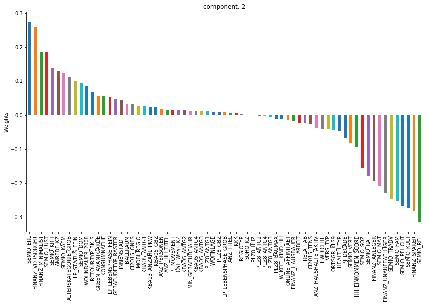

```python
# Map weights for the second principal component to corresponding feature names
# and then print the linked values, sorted by weight.

weight_map(pca,scaled_df,1)
```

```
SEMIO_VERT               0.3249
FINANZ_MINIMALIST        0.2596
SEMIO_SOZ                0.2120
SEMIO_KULT               0.1928
SEMIO_FAM                0.1870
LP_STATUS_FEIN           0.1556
FINANZ_VORSORGER         0.1046
GREEN_AVANTGARDE         0.1045
KONSUMNAEHE              0.0924
INNENSTADT               0.0774
ANZ_PERSONEN             0.0764
LP_LEBENSPHASE_FEIN      0.0719
GEBAEUDETYP_RASTER       0.0647
WOHNDAUER_2008           0.0630
BALLRAUM                 0.0622
RETOURTYP_BK_S           0.0570
WOHNLAGE                 0.0566
SEMIO_LUST               0.0484
ONLINE_AFFINITAET        0.0482
KBA13_ANZAHL_PKW         0.0398
SEMIO_REL                0.0254
SEMIO_MAT                0.0226
KKK                      0.0220
ALTERSKATEGORIE_GROB     0.0203
MOBI_REGIO               0.0196
KBA05_ANTG1              0.0176
OST_WEST_KZ              0.0175
REGIOTYP                 0.0175
KBA05_GBZ                0.0164
CI2015_ONES              0.0159
                          ...
W_KEIT_KIND_HH          -0.0322
PLZ8_ANTG1              -0.0370
PLZ8_GBZ                -0.0391
ARBEIT                  -0.0455
RELAT_AB                -0.0507
CI2015_TENS             -0.0512
PLZ8_HHZ                -0.0543
PLZ8_ANTG2              -0.0604
PLZ8_ANTG4              -0.0610
PLZ8_ANTG3              -0.0651
SEMIO_TRADV             -0.0683
PLZ8_BAUMAX             -0.0696
ANZ_HAUSHALTE_AKTIV     -0.0745
EWDICHTE                -0.0842
ORTSGR_KLS9             -0.0880
PJ_DECADE               -0.0924
FINANZ_UNAUFFAELLIGER   -0.0925
VERS_TYP                -0.0934
HEALTH_TYP              -0.0942
SEMIO_PFLICHT           -0.0969
FINANZ_SPARER           -0.1342
SEMIO_ERL               -0.1440
HH_EINKOMMEN_SCORE      -0.1505
FINANZ_ANLEGER          -0.1552
FINANZ_HAUSBAUER        -0.1701
SEMIO_RAT               -0.2046
SEMIO_KRIT              -0.2548
SEMIO_DOM               -0.2825
SEMIO_KAEM              -0.3204
ANREDE_KZ               -0.3245
Name: 2, Length: 69, dtype: float64
```

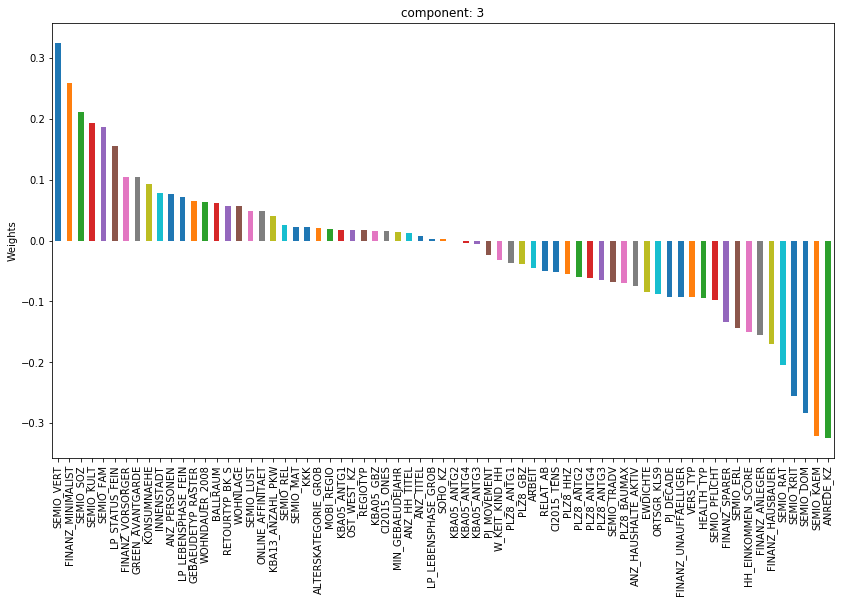

```python
# Map weights for the third principal component to corresponding feature names
# and then print the linked values, sorted by weight.

weight_map(pca,scaled_df,2)
```

### Discussion 2.3: Interpret Principal Components

(Double-click this cell and replace this text with your own text, reporting your observations from detailed investigation of the first few principal components generated. Can we interpret positive and negative values from them in a meaningful way?)

Not straightforward. Many of those relationships i find them quite suprising.

## Step 3: Clustering

### Step 3.1: Apply Clustering to General Population

You've assessed and cleaned the demographics data, then scaled and transformed them. Now, it's time to see how the data clusters in the principal components space. In this substep, you will apply k-means clustering to the dataset and use the average within-cluster distances from each point to their assigned cluster's centroid to decide on a number of clusters to keep.

- Use sklearn's KMeans class to perform k-means clustering on the PCA-transformed data.
- Then, compute the average difference from each point to its assigned cluster's center. **Hint**: The KMeans object's `.score()` method might be useful here, but note that in sklearn, scores tend to be defined so that larger is better. Try applying it to a small, toy dataset, or use an internet search to help your understanding.
- Perform the above two steps for a number of different cluster counts. You can then see how the average distance decreases with an increasing number of clusters. However, each additional cluster provides a smaller net benefit. Use this fact to select a final number of clusters in which to group the data. **Warning**: because of the large size of the dataset, it can take a long time for the algorithm to resolve. The more clusters to fit, the longer the algorithm will take. You should test for cluster counts through at least 10 clusters to get the full picture, but you shouldn't need to test for a number of clusters above about 30.
- Once you've selected a final number of clusters to use, re-fit a KMeans instance to perform the clustering operation. Make sure that you also obtain the cluster assignments for the general demographics data, since you'll be using them in the final Step 3.3.

```python
from sklearn.cluster import KMeans

sse = []
random_state = 17

# Over a number of different cluster counts...
for cl_count in range(3,16):

    # run k-means clustering on the data and...
    kmeans = KMeans(n_clusters=cl_count, random_state=random_state)
    kmeans.fit(df_pca)

    # compute the average within-cluster distances.
    sse.append([cl_count,kmeans.inertia_])

    #debug
    print(f"cl_count: {cl_count} inertia: {kmeans.inertia_}")
```

[output not shown]

```
Text(0,0.5,'Inertia')
```

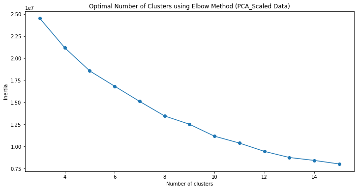

```python
# Investigate the change in within-cluster distance across number of clusters.
# HINT: Use matplotlib's plot function to visualize this relationship.

plt.figure(figsize=(12,6))
plt.plot(pd.DataFrame(sse)[0], pd.DataFrame(sse)[1], marker='o')
plt.title('Optimal Number of Clusters using Elbow Method (PCA_Scaled Data)')
plt.xlabel('Number of clusters')
plt.ylabel('Inertia')
```

```python
# Re-fit the k-means model with the selected number of clusters and obtain
# cluster predictions for the general population demographics data.

n_clusters = 13

kmeans_pca_scale = KMeans(n_clusters=n_clusters, n_init=100, max_iter=400, init='k-means++', random_state=17).fit(df_pca)
labels_pca = kmeans_pca_scale.predict(df_pca)


#print('KMeans PCA Scaled Silhouette Score: {}'.format(silhouette_score(df_pca, kmeans_pca_scale.labels_, metric='euclidean')))
#labels_pca_scale = kmeans_pca_scale.labels_
#clusters_pca_scale = pd.concat([df_pca, pd.DataFrame({'pca_clusters':labels_pca_scale})], axis=1)
```

```python
labels_pca.shape #(797961,)
#labels_pca
```

```
(797961,)
```

```python
df_pca.shape #(797961, 10)
```

```
(797961, 10)
```

```python
#cluster memberships
pca_df_scale = pd.DataFrame(df_pca, columns=['pc1','pc2','pc3','pc4','pc5','pc6','pc7','pc8','pc9','pc10']) #principal comp.
clusters = pd.concat([pca_df_scale, pd.DataFrame({'clusters':labels_pca})], axis=1)

clusters
```

|  | pc1 | pc2 | pc3 | pc4 | pc5 | pc6 | pc7 | pc8 | pc9 | pc10 | clusters |
| --- | --- | --- | --- | --- | --- | --- | --- | --- | --- | --- | --- |
| 0 | -1.148819 | -2.820760 | -2.935041 | 1.120532 | -0.573339 | -1.287616 | -0.522239 | 0.295205 | -0.058788 | -0.839275 | 1 |
| 1 | -1.101169 | 1.101345 | -2.698008 | 0.272896 | -1.075304 | -0.537674 | 0.332166 | -0.748956 | -1.081615 | 0.193782 | 4 |
| 2 | 0.779761 | 3.157650 | 1.045838 | 2.793753 | 2.165006 | 0.816116 | -1.256965 | 1.155447 | 0.805524 | -1.498283 | 0 |
| 3 | -0.658884 | -0.107126 | 3.085074 | -1.170489 | 0.638761 | 0.589328 | 1.031136 | 0.064652 | -0.312622 | 0.254634 | 6 |
| 4 | -0.639742 | -0.993841 | -0.474577 | 1.302598 | -0.874170 | -1.610566 | -1.595468 | 0.923152 | 0.402512 | -0.176989 | 1 |
| 5 | -0.685172 | -2.787575 | -3.159314 | 1.818590 | -1.406674 | -1.334940 | 0.108724 | 0.674853 | -0.230576 | -0.362307 | 1 |
| 6 | -0.695312 | -3.359296 | 3.022846 | -1.464096 | -0.715790 | 0.132420 | -0.093454 | -1.194748 | -1.050642 | 0.009658 | 9 |
| 7 | -0.746174 | 0.461401 | 1.753045 | 0.056893 | -0.255715 | -0.657958 | 1.154333 | -0.778107 | -1.384607 | 0.341672 | 6 |
| 8 | -0.915912 | 1.726469 | -2.827803 | 0.943751 | -0.949401 | -1.139744 | -0.586021 | -0.777293 | -0.213608 | -0.040562 | 4 |
| 9 | -1.319923 | 1.855149 | -1.789011 | -0.789772 | -0.945411 | 0.060803 | -0.994184 | 0.976471 | 0.646403 | -0.521343 | 4 |
| 10 | 8.661116 | 0.499902 | 2.309889 | 3.350135 | -2.841416 | 6.607062 | 0.004886 | -1.775338 | -0.326631 | 0.676126 | 5 |
| 11 | 8.351770 | -0.984253 | -1.989754 | 6.344856 | -4.380955 | 4.758554 | -0.773501 | 0.361097 | 0.272082 | -0.057009 | 5 |
| 12 | 6.685124 | 3.041556 | -3.414231 | -7.803014 | 2.201199 | -4.648769 | 1.572762 | -0.512994 | -0.241552 | -1.575863 | 7 |
| 13 | 0.069651 | -2.101493 | -1.199915 | 3.661325 | 2.647198 | -0.927026 | -1.237083 | 0.194824 | 1.309814 | -0.761953 | 1 |
| 14 | 0.904416 | -1.874397 | -1.516085 | 2.862599 | -0.914552 | -0.264499 | -0.074516 | 0.630792 | 0.887896 | -0.484711 | 1 |
| 15 | -0.273371 | 0.645079 | 2.718691 | -0.487783 | 0.225087 | -0.187765 | 1.983684 | -0.707385 | -1.710574 | 0.743301 | 6 |
| 16 | 9.614771 | -0.809388 | -3.151810 | -2.175762 | 1.205143 | -7.077000 | 1.875297 | 0.434819 | -0.450654 | -1.157122 | 7 |
| 17 | -0.286015 | -4.837750 | 2.358919 | -1.127712 | -0.575686 | 0.198823 | 1.437456 | -0.536134 | -0.394107 | 0.867184 | 9 |
| 18 | -0.761149 | -5.633578 | 0.664581 | -1.392676 | -0.744358 | 0.329437 | -1.157994 | 0.072597 | 0.456531 | -0.593037 | 9 |
| 19 | 7.742740 | -0.271183 | 0.111304 | -5.706021 | 2.523184 | -6.365326 | 2.357895 | -0.120229 | -0.836853 | -0.743393 | 7 |
| 20 | 0.031203 | -4.629542 | 3.033818 | 2.606048 | 4.048445 | -0.049543 | -1.850081 | 1.887631 | 1.680054 | -1.416442 | 9 |
| 21 | 19.820308 | -0.093642 | 0.650752 | -3.634860 | -0.350933 | -2.253619 | -1.580228 | 3.833734 | 5.017939 | 12.088740 | 2 |
| 22 | -0.588352 | 0.190633 | 1.096543 | -1.686715 | -0.207962 | 0.600670 | 1.805628 | -1.225500 | -1.435910 | 0.608831 | 3 |
| 23 | -0.696419 | -0.270369 | 2.028297 | -0.424219 | -0.724412 | -0.542977 | -1.579361 | 0.225315 | -0.761571 | -0.530655 | 6 |
| 24 | 0.398848 | 3.674003 | 0.651612 | 1.628613 | -1.178960 | -0.225400 | 0.636023 | 0.257252 | -0.978523 | -0.355826 | 0 |
| 25 | -1.089916 | -3.330810 | -4.135827 | -0.710931 | -1.983449 | 0.140607 | 1.501604 | -1.283232 | -0.806827 | 0.345857 | 1 |
| 26 | -0.131565 | -3.326504 | 4.845163 | 0.919578 | 0.182151 | -1.059452 | 0.945670 | 0.799495 | -1.389606 | 0.162761 | 9 |
| 27 | -1.069926 | -0.423851 | -2.923754 | -0.365501 | -0.518467 | 0.201977 | 2.275978 | -1.466042 | -1.330106 | 0.333105 | 1 |
| 28 | -0.852213 | 1.379614 | -1.985131 | 0.872457 | 3.534135 | 1.350446 | 1.418256 | -0.288864 | -2.762478 | 1.416001 | 11 |
| 29 | -1.430760 | 1.386949 | -3.337220 | -0.971329 | -1.340784 | 0.485199 | 0.458602 | -0.507940 | -0.318378 | -0.311515 | 4 |
| ... | ... | ... | ... | ... | ... | ... | ... | ... | ... | ... | ... |
| 797931 | -1.124200 | 3.811298 | -0.804180 | -0.479571 | -0.363008 | -0.438181 | -1.302564 | -1.119527 | 0.392828 | -0.128837 | 4 |
| 797932 | -0.970919 | -2.694619 | -3.315440 | 1.689554 | -0.477070 | -1.016526 | -0.720471 | -0.036910 | 0.274876 | -0.438044 | 1 |
| 797933 | -1.140188 | 0.404808 | 2.575391 | -2.054027 | -0.256491 | 0.730528 | -0.412339 | 0.120102 | 0.010857 | 0.149753 | 3 |
| 797934 | -0.138108 | 0.256616 | 2.651972 | -0.260757 | 0.014250 | 0.311662 | 2.305716 | -0.189369 | -1.255566 | 0.602799 | 6 |
| 797935 | -1.474790 | 4.560943 | -1.148821 | -1.319138 | 0.390734 | 0.663554 | -0.284901 | 0.451729 | 0.457810 | 0.080882 | 4 |
| 797936 | -0.707342 | -2.705045 | -2.934013 | 2.368440 | -0.353029 | -1.422635 | 0.351793 | 0.742042 | 0.240933 | -0.220612 | 1 |
| 797937 | -1.090408 | 3.198281 | -1.934345 | -0.370547 | -0.704824 | 0.088031 | 2.501485 | -1.021821 | -1.176470 | 0.567098 | 4 |
| 797938 | -0.795122 | -1.150151 | 0.100826 | -0.755111 | -0.783803 | 0.330755 | 1.520454 | -0.559887 | -1.808233 | 0.018261 | 3 |
| 797939 | -0.788671 | -4.419435 | 0.778621 | -1.543896 | -1.046706 | -0.099828 | -0.252837 | -0.493754 | -0.239219 | -0.015834 | 9 |
| 797940 | -0.990409 | -3.640975 | -2.585766 | 0.867547 | -0.540318 | -0.533181 | 1.351363 | 0.065108 | -0.779654 | 0.448920 | 1 |
| 797941 | -0.809615 | -0.340754 | 1.158248 | -1.486995 | -0.930738 | 0.281546 | 0.441382 | -0.234733 | -0.189146 | -0.127014 | 3 |
| 797942 | -1.207000 | -2.880729 | -3.674480 | -1.355871 | -1.754685 | 0.225100 | 1.358703 | -1.870232 | -0.125095 | -0.062402 | 1 |
| 797943 | 7.647742 | 3.263336 | -2.364063 | 3.339840 | 1.481284 | 9.631711 | -1.013676 | -1.361443 | 0.258842 | 0.045737 | 5 |
| 797944 | -0.671855 | -0.090123 | 2.885558 | 0.489983 | 0.668622 | -0.465530 | 1.433415 | 0.441031 | -0.726339 | 0.348356 | 6 |
| 797945 | -1.009397 | 0.217148 | 1.760802 | -1.828083 | 0.307203 | 0.923312 | -0.251671 | -0.065310 | -0.237729 | -0.095601 | 3 |
| 797946 | -0.426391 | -1.516421 | -1.818099 | 2.629068 | -0.961990 | -1.988918 | 0.306971 | 0.927412 | -0.363421 | 0.079594 | 1 |
| 797947 | -0.902815 | 3.883307 | -1.057430 | 0.551727 | -0.418282 | -1.039440 | 0.544936 | -0.928989 | -0.993755 | 0.012056 | 0 |
| 797948 | 0.968223 | 0.819119 | 3.652975 | 1.969753 | 0.611659 | 0.482245 | -1.499208 | 2.280614 | 0.453063 | -1.060199 | 6 |
| 797949 | -0.857491 | -1.659347 | -3.078494 | 0.850634 | -0.336223 | -0.870552 | 0.170659 | 0.431362 | 0.155744 | -0.443012 | 1 |
| 797950 | -1.175908 | -1.095141 | 0.216466 | -2.634645 | -0.895134 | 1.289200 | 0.515056 | -1.439034 | 0.301395 | -0.372410 | 3 |
| 797951 | -0.923351 | -0.240178 | 0.501789 | -0.749617 | -0.882515 | -0.024575 | -0.738404 | 0.710791 | -0.200806 | -0.112750 | 3 |
| 797952 | -1.655711 | 1.237608 | 1.649890 | -4.796311 | -0.383338 | 2.124810 | -0.790994 | -1.223949 | 0.099114 | -0.298323 | 3 |
| 797953 | -0.481863 | 1.732474 | -0.528778 | 2.175171 | 0.571903 | -1.454793 | 2.341177 | -0.139760 | -1.818132 | 0.701509 | 0 |
| 797954 | -1.027669 | -1.607250 | -3.391953 | -0.123056 | -1.325690 | -0.562361 | 0.365604 | -0.536708 | -0.215866 | -0.311905 | 1 |
| 797955 | -1.000535 | -2.733940 | -3.908027 | 0.748287 | -1.461945 | -0.883069 | 0.088999 | -1.322341 | -1.051766 | -0.139912 | 1 |
| 797956 | -1.703786 | -1.040623 | -4.972373 | -3.824732 | -2.272456 | 6.172704 | 9.236639 | 12.580441 | 1.882658 | -2.533049 | 10 |
| 797957 | -1.242551 | -1.055568 | -1.080890 | -1.417799 | 3.044819 | 1.864850 | -1.054588 | 0.109537 | -1.474081 | 0.559234 | 11 |
| 797958 | -0.470217 | -1.927472 | -1.682468 | 3.320738 | 2.333048 | -1.059528 | -1.052044 | 0.886921 | 1.538010 | -0.777781 | 1 |
| 797959 | -0.920960 | -5.416818 | 0.817923 | -1.066008 | 0.149025 | 0.566199 | 0.011283 | -0.011461 | 0.611414 | -0.335559 | 9 |
| 797960 | -0.857994 | 0.078291 | 2.619942 | -1.933831 | -0.804626 | 0.213975 | -2.387048 | 1.144584 | 0.186222 | -0.434416 | 3 |

797961 rows × 11 columns

### Discussion 3.1: Apply Clustering to General Population

(Double-click this cell and replace this text with your own text, reporting your findings and decisions regarding clustering. Into how many clusters have you decided to segment the population?)

I think 13 clusters look good according to the Knie graph.

### Step 3.2: Apply All Steps to the Customer Data

Now that you have clusters and cluster centers for the general population, it's time to see how the customer data maps on to those clusters. Take care to not confuse this for re-fitting all of the models to the customer data. Instead, you're going to use the fits from the general population to clean, transform, and cluster the customer data. In the last step of the project, you will interpret how the general population fits apply to the customer data.

- Don't forget when loading in the customers data, that it is semicolon (`;`) delimited.
- Apply the same feature wrangling, selection, and engineering steps to the customer demographics using the `clean_data()` function you created earlier. (You can assume that the customer demographics data has similar meaning behind missing data patterns as the general demographics data.)
- Use the sklearn objects from the general demographics data, and apply their transformations to the customers data. That is, you should not be using a `.fit()` or `.fit_transform()` method to re-fit the old objects, nor should you be creating new sklearn objects! Carry the data through the feature scaling, PCA, and clustering steps, obtaining cluster assignments for all of the data in the customer demographics data.

```python
# Load in the customer demographics data.
customers = pd.read_csv("Udacity_CUSTOMERS_Subset.csv",delimiter=';')
```

```python
#cleaning
df_cust_cleaned = clean_data(customers)
```

```python
# Apply preprocessing, feature transformation, and clustering from the general
# demographics onto the customer data, obtaining cluster predictions for the
# customer demographics data.

#scaling
scaled_cust_df = pd.DataFrame(scaler.transform(df_cust_cleaned))
scaled_cust_df.columns = df_cust_cleaned.columns
scaled_cust_df.index = df_cust_cleaned.index
```

```python
#PCA
pca_cust_df = pca.transform(scaled_cust_df)
```

```python
#KMeans - prediction for customers data
n_clusters = 13
labels_cust_pca = kmeans_pca_scale.predict(pca_cust_df)

#cluster memberships
pca_cust_df_scale = pd.DataFrame(pca_cust_df, columns=['pc1','pc2','pc3','pc4','pc5','pc6','pc7','pc8','pc9','pc10']) #principal comp.
cust_clusters = pd.concat([pca_cust_df_scale, pd.DataFrame({'clusters':labels_cust_pca})], axis=1)

cust_clusters
```

|  | pc1 | pc2 | pc3 | pc4 | pc5 | pc6 | pc7 | pc8 | pc9 | pc10 | clusters |
| --- | --- | --- | --- | --- | --- | --- | --- | --- | --- | --- | --- |
| 0 | -0.627148 | 0.749886 | 2.868958 | -0.878499 | -0.153087 | 0.669449 | 1.533796 | -0.776805 | -1.620834 | -0.920286 | 6 |
| 1 | -0.856944 | -1.202083 | -3.109969 | 0.614268 | -0.545215 | 0.226911 | 1.609278 | 1.840622 | -0.421505 | -1.457298 | 1 |
| 2 | -0.267847 | 0.816320 | 0.997817 | -0.992191 | 14.440795 | 6.180517 | -0.891694 | -1.207150 | 1.475581 | 0.541798 | 11 |
| 3 | -0.219150 | -0.429862 | 0.465822 | -0.471953 | -0.298511 | -1.427797 | -2.408429 | -1.235674 | 1.875761 | -0.357675 | 3 |
| 4 | -0.725231 | -0.301162 | 1.380593 | -0.302923 | -0.102201 | -0.501073 | 1.032155 | 1.011310 | -0.099973 | -0.022721 | 6 |
| 5 | -0.634757 | 0.699789 | 1.918214 | -0.840122 | -0.498070 | 1.178087 | 1.105778 | -0.963577 | -0.791397 | 0.061623 | 3 |
| 6 | -0.742495 | 0.655134 | 2.650507 | -0.569712 | 0.107315 | -0.607880 | 1.287161 | 0.634288 | -1.185592 | -0.764773 | 6 |
| 7 | 0.177607 | -3.055489 | -5.542467 | 0.713623 | 1.456154 | -0.932701 | -1.737068 | -0.577053 | -1.419439 | -0.188167 | 1 |
| 8 | -0.110667 | 0.621959 | 2.059296 | -0.559183 | -0.735603 | 0.464676 | 0.810053 | 1.110817 | 0.863813 | 0.369026 | 6 |
| 9 | -0.406523 | 0.806777 | 2.668272 | -0.686187 | 0.102914 | -0.857576 | -0.024077 | -0.246755 | -0.037426 | -1.653985 | 6 |
| 10 | -0.149364 | 0.179257 | 2.246969 | -1.262714 | -0.759593 | 1.795975 | -0.318154 | -2.599625 | -0.305925 | 0.724315 | 3 |
| 11 | 7.275431 | 0.101202 | 0.810077 | -0.609175 | -1.256820 | 2.424471 | -3.262451 | 2.841437 | -3.753757 | -0.013487 | 5 |
| 12 | -1.125180 | -2.754167 | -4.192870 | 0.611236 | 0.213253 | -1.547255 | -0.033088 | 0.119915 | -1.479419 | -0.344063 | 1 |
| 13 | -0.647224 | 1.120895 | 3.087110 | -0.541258 | -0.743807 | -0.027936 | 1.168159 | 1.470389 | 1.476358 | -0.622958 | 6 |
| 14 | -0.658994 | 1.031414 | 2.831107 | -0.622173 | 0.161400 | -0.697009 | 0.590996 | 0.841119 | 0.012824 | -0.682471 | 6 |
| 15 | -0.252164 | 1.290581 | 2.311978 | -0.627448 | -1.320361 | 0.974364 | 1.041194 | 0.815256 | 1.715420 | -0.260210 | 6 |
| 16 | -0.399547 | -1.333604 | 0.970598 | -0.428993 | 0.757490 | -4.009150 | -4.052751 | -1.090282 | 1.999959 | -0.996715 | 9 |
| 17 | -0.682856 | -2.635269 | -4.253457 | 0.371233 | -0.587422 | 0.525375 | -0.006430 | 0.081313 | -0.705895 | 0.308358 | 1 |
| 18 | 5.946554 | 0.458298 | 1.104937 | -0.081315 | -1.150012 | 1.186263 | -1.678996 | 5.394548 | -2.841038 | -1.399830 | 6 |
| 19 | -0.395201 | -1.713867 | 0.474769 | -0.688124 | 0.702692 | -1.105342 | -1.695941 | -3.050021 | -1.020640 | -0.927127 | 3 |
| 20 | -0.200143 | -0.831563 | -0.347687 | -0.582296 | -1.526909 | 2.419315 | -0.520161 | -1.412091 | 2.389447 | -0.252756 | 3 |
| 21 | -0.650719 | -2.082728 | -0.931385 | 0.001039 | 1.289784 | -3.329314 | -2.292895 | -0.797122 | -0.068577 | -0.790183 | 1 |
| 22 | -0.902300 | -0.827962 | -1.985747 | 0.045512 | -0.787727 | 1.048420 | 1.196801 | 0.199570 | -0.646847 | 0.744250 | 1 |
| 23 | -0.119651 | 0.341998 | -0.277745 | -0.472631 | -2.447055 | 3.504926 | 1.022277 | 0.307474 | 2.924081 | 0.296466 | 3 |
| 24 | -0.747659 | -0.931047 | -2.385585 | -0.349772 | -0.920978 | 3.134237 | 1.542167 | -1.870554 | -0.948023 | 0.875210 | 1 |
| 25 | -0.498598 | 0.763549 | 2.363564 | -0.292909 | -0.422974 | -1.423294 | 0.174125 | 1.644438 | 1.942693 | -0.158508 | 6 |
| 26 | -0.901184 | -2.205876 | -4.167343 | 0.472848 | 0.421008 | -0.813557 | -0.245328 | -0.608871 | -1.218039 | 0.218426 | 1 |
| 27 | -0.870583 | -2.723945 | -3.468495 | 0.515904 | 0.170890 | -1.851166 | -1.094842 | 0.241084 | 0.208055 | -0.706208 | 1 |
| 28 | -0.774523 | -0.279340 | -2.161288 | -0.011633 | -1.338148 | 1.868462 | 1.257377 | 0.304571 | 0.779020 | -0.434870 | 1 |
| 29 | -0.267034 | 0.570040 | 2.081393 | -0.926089 | -1.138688 | 1.885659 | 0.574095 | -0.842371 | 1.160080 | 0.747054 | 3 |
| ... | ... | ... | ... | ... | ... | ... | ... | ... | ... | ... | ... |
| 141683 | -0.560366 | -0.573483 | 1.787311 | -0.965974 | 0.004468 | -0.001716 | -0.563245 | -2.135108 | -1.119069 | 0.168424 | 3 |
| 141684 | -0.592854 | 0.854932 | 2.249804 | -0.499503 | -0.703338 | 0.577562 | 1.703729 | 1.269717 | 0.810153 | -0.074427 | 6 |
| 141685 | -0.408529 | 0.295734 | 2.466807 | -0.568375 | 0.167264 | -1.143815 | 0.153732 | 0.509498 | 0.153085 | -1.776616 | 6 |
| 141686 | -1.019037 | -0.442821 | -2.401995 | 0.293684 | -0.958801 | 1.600200 | 2.524720 | 1.224438 | -0.482074 | -0.613081 | 1 |
| 141687 | 0.021044 | -0.808766 | 1.740125 | -0.645458 | 0.521555 | -3.019039 | -3.115256 | -0.730214 | 1.096858 | -0.285867 | 6 |
| 141688 | -0.883041 | -2.738316 | -3.964626 | 0.405494 | 0.049600 | -1.162248 | -1.032934 | -1.033627 | -0.360111 | -0.423351 | 1 |
| 141689 | -0.693525 | 0.331197 | 2.399817 | -0.443587 | 0.066026 | -0.806798 | 1.309329 | 1.209235 | -0.681644 | -1.670936 | 6 |
| 141690 | -1.352765 | -2.520944 | -4.404797 | 0.552750 | 1.867690 | -1.025250 | -0.101146 | -1.091837 | -1.326561 | -0.948093 | 1 |
| 141691 | -0.578439 | -0.665151 | 1.886750 | -0.397558 | 0.304388 | -1.462902 | 0.166926 | 0.742101 | -0.568297 | -0.368976 | 6 |
| 141692 | -1.220822 | -2.215771 | -4.133806 | 0.563975 | 3.006663 | -1.374107 | -0.550531 | -0.009660 | -1.285883 | -0.322278 | 1 |
| 141693 | -0.834907 | 0.077512 | 0.779091 | -0.802172 | -0.581657 | 1.032676 | 0.233288 | -1.822903 | -0.655468 | 1.244359 | 3 |
| 141694 | -0.727013 | 0.860293 | 0.855575 | -0.300080 | -0.641076 | 0.786934 | 1.982406 | 1.540627 | -0.160100 | -0.039344 | 6 |
| 141695 | -0.497444 | 0.331198 | 0.900576 | -0.994865 | -0.751670 | 1.524329 | -0.090372 | -2.587401 | -0.580001 | 1.210729 | 3 |
| 141696 | -0.821807 | -0.748046 | -2.888061 | 0.112102 | -0.398261 | 1.145622 | 1.186819 | 0.117235 | -1.047604 | 0.726513 | 1 |
| 141697 | -1.194350 | 0.411656 | 4.554876 | 13.648638 | 0.039199 | 0.715548 | 0.299237 | -0.334607 | -1.320462 | 0.066199 | 6 |
| 141698 | -0.855763 | -0.249660 | -1.546570 | 0.404958 | -1.213143 | 0.247324 | 0.974145 | 2.483487 | 2.151606 | -0.272029 | 1 |
| 141699 | -1.038569 | -1.124892 | 0.126681 | -0.352859 | 0.755753 | -1.742273 | -0.619252 | -1.195166 | -1.175781 | 0.742810 | 3 |
| 141700 | 7.812185 | 0.191296 | 1.126473 | -0.738107 | -1.530723 | 1.761061 | -6.036340 | 2.759161 | -1.556351 | -0.849293 | 5 |
| 141701 | -0.591998 | 0.838183 | 1.952445 | -0.362016 | 0.058141 | -1.139341 | 0.238089 | 1.046007 | 0.829604 | -0.126789 | 6 |
| 141702 | -0.516371 | 0.945133 | 2.990532 | -0.929436 | -0.031851 | 0.089785 | 0.613343 | -1.020423 | -1.005129 | -1.070685 | 6 |
| 141703 | -1.250335 | -2.949325 | -4.589732 | 0.609359 | 0.567345 | -1.641780 | -1.032394 | -0.463511 | -1.685107 | -0.218861 | 1 |
| 141704 | -0.622152 | 1.243003 | 2.180931 | -0.535671 | -0.803288 | 0.984868 | 2.078282 | 1.195120 | 0.213156 | -0.371109 | 6 |
| 141705 | -1.127924 | -1.786777 | -3.660295 | 0.534804 | 0.001596 | -0.457142 | 0.821036 | 0.286796 | -0.531061 | -0.214063 | 1 |
| 141706 | -0.623836 | 0.756760 | 2.171322 | -0.652094 | -0.600239 | -0.951503 | -0.329112 | -0.502262 | 0.401355 | 0.895922 | 6 |
| 141707 | -0.500318 | -2.514029 | -3.077830 | 0.319917 | -0.307943 | -2.045286 | -3.378291 | -0.031603 | 2.721491 | -0.861711 | 1 |
| 141708 | -0.611999 | -0.118768 | 1.269750 | -0.053518 | 0.188852 | -2.012387 | 0.202288 | 2.038079 | 0.665074 | -1.461877 | 6 |
| 141709 | 13.983700 | -0.450034 | -4.843286 | 1.407552 | 22.926240 | 2.358330 | 12.845648 | -6.163919 | 8.037346 | 3.028115 | 8 |
| 141710 | -0.833693 | -0.021476 | 0.633278 | -0.290959 | -0.185024 | 0.338602 | 2.120488 | 0.829441 | -1.418509 | 1.308645 | 6 |
| 141711 | -1.056638 | -1.733872 | -3.645655 | 0.444433 | -0.659919 | -0.397478 | -0.528563 | -0.008966 | 0.679221 | -0.121319 | 1 |
| 141712 | -0.176336 | 0.101599 | 2.823623 | -1.292097 | -0.451683 | 0.745527 | -1.780189 | -2.460415 | 1.793275 | 0.177046 | 3 |

141713 rows × 11 columns

### Step 3.3: Compare Customer Data to Demographics Data

At this point, you have clustered data based on demographics of the general population of Germany, and seen how the customer data for a mail-order sales company maps onto those demographic clusters. In this final substep, you will compare the two cluster distributions to see where the strongest customer base for the company is.

Consider the proportion of persons in each cluster for the general population, and the proportions for the customers. If we think the company's customer base to be universal, then the cluster assignment proportions should be fairly similar between the two. If there are only particular segments of the population that are interested in the company's products, then we should see a mismatch from one to the other. If there is a higher proportion of persons in a cluster for the customer data compared to the general population (e.g. 5% of persons are assigned to a cluster for the general population, but 15% of the customer data is closest to that cluster's centroid) then that suggests the people in that cluster to be a target audience for the company. On the other hand, the proportion of the data in a cluster being larger in the general population than the customer data (e.g. only 2% of customers closest to a population centroid that captures 6% of the data) suggests that group of persons to be outside of the target demographics.

Take a look at the following points in this step:

- Compute the proportion of data points in each cluster for the general population and the customer data. Visualizations will be useful here: both for the individual dataset proportions, but also to visualize the ratios in cluster representation between groups. Seaborn's [`countplot()`](https://seaborn.pydata.org/generated/seaborn.countplot.html) or [`barplot()`](https://seaborn.pydata.org/generated/seaborn.barplot.html) function could be handy.
  - Recall the analysis you performed in step 1.1.3 of the project, where you separated out certain data points from the dataset if they had more than a specified threshold of missing values. If you found that this group was qualitatively different from the main bulk of the data, you should treat this as an additional data cluster in this analysis. Make sure that you account for the number of data points in this subset, for both the general population and customer datasets, when making your computations!
- Which cluster or clusters are overrepresented in the customer dataset compared to the general population? Select at least one such cluster and infer what kind of people might be represented by that cluster. Use the principal component interpretations from step 2.3 or look at additional components to help you make this inference. Alternatively, you can use the `.inverse_transform()` method of the PCA and StandardScaler objects to transform centroids back to the original data space and interpret the retrieved values directly.
- Perform a similar investigation for the underrepresented clusters. Which cluster or clusters are underrepresented in the customer dataset compared to the general population, and what kinds of people are typified by these clusters?

```
Text(0.5,0,'Cluster membership')
```

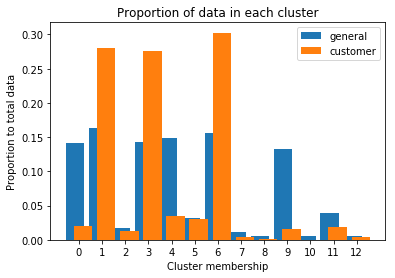

```python
# Compare the proportion of data in each cluster for the customer data to the
# proportion of data in each cluster for the general population.
n_general = clusters.shape[0]
data_general = clusters.groupby(['clusters'])['clusters'].count()/n_general

n_customer = cust_clusters.shape[0]
data_customer = cust_clusters.groupby(['clusters'])['clusters'].count()/n_customer

fig, ax = plt.subplots()
width = 0.35
general = ax.bar(data_general.index - width/2, data_general, label='general')
customer = ax.bar(data_customer.index + width/2, data_customer, label='customer')
ax.set_xticks(data_general.index)
ax.legend()
ax.set_title("Proportion of data in each cluster")
ax.set_ylabel("Proportion to total data")
ax.set_xlabel("Cluster membership")
```

```python
# What kinds of people are part of a cluster that is overrepresented in the
# customer data compared to the general population?

#overrepresented = where customer demographic proportion > general demographic proportion
# these are cluster: 1, 3, 6... i'll pick 6

cust_re_orig = scaler.inverse_transform(pca.inverse_transform(pca_cust_df))
cust_re_orig_df = pd.DataFrame(cust_re_orig)
cust_re_orig_df.columns = df_cust_cleaned.columns

#these are the groups of customers that belong to cluster = 6 which is overrepresented
print("these are the groups of customers that belong to cluster = 6 which is overrepresented")
cust_re_orig_df[cust_clusters['clusters'] == 6].describe()
```

```
these are the groups of customers that belong to cluster = 6 which is overrepresented
```

|  | ALTERSKATEGORIE_GROB | ANREDE_KZ | FINANZ_MINIMALIST | FINANZ_SPARER | FINANZ_VORSORGER | FINANZ_ANLEGER | FINANZ_UNAUFFAELLIGER | FINANZ_HAUSBAUER | GREEN_AVANTGARDE | HEALTH_TYP | ... | PLZ8_BAUMAX | PLZ8_HHZ | PLZ8_GBZ | ARBEIT | ORTSGR_KLS9 | RELAT_AB | PJ_MOVEMENT | PJ_DECADE | CI2015_TENS | CI2015_ONES |
| --- | --- | --- | --- | --- | --- | --- | --- | --- | --- | --- | --- | --- | --- | --- | --- | --- | --- | --- | --- | --- | --- |
| count | 42876.000000 | 42876.000000 | 42876.000000 | 42876.000000 | 42876.000000 | 42876.000000 | 42876.000000 | 42876.000000 | 42876.000000 | 42876.000000 | ... | 42876.000000 | 42876.000000 | 42876.000000 | 42876.000000 | 42876.000000 | 42876.000000 | 42876.000000 | 42876.000000 | 42876.000000 | 42876.000000 |
| mean | 3.654202 | 0.976691 | 4.821693 | 1.227535 | 4.739687 | 1.082621 | 1.787519 | 2.296114 | 0.868856 | 1.773116 | ... | 1.518006 | 3.709522 | 3.702373 | 3.083417 | 5.931871 | 3.199227 | 29.778729 | 2.449195 | 2.259120 | 3.645426 |
| std | 0.472428 | 0.141881 | 0.544192 | 0.438882 | 0.434130 | 0.444943 | 0.374881 | 0.714601 | 0.270707 | 1.245628 | ... | 1.152378 | 1.005654 | 1.089863 | 1.221594 | 1.601860 | 1.298850 | 5.701230 | 0.863221 | 0.698405 | 0.215495 |
| min | 1.603481 | 0.469595 | 2.324915 | 0.303734 | 2.699513 | -0.019266 | 0.916970 | -1.019197 | -0.310304 | -1.188663 | ... | -0.360224 | 2.201819 | 1.610111 | -0.964706 | 0.348056 | -1.090070 | 9.921632 | 0.750661 | -0.102874 | 2.574000 |
| 25% | 3.416882 | 0.874024 | 4.544599 | 0.921332 | 4.520749 | 0.773791 | 1.522373 | 1.791942 | 0.746112 | 0.909069 | ... | 1.076364 | 3.439432 | 3.301022 | 2.203679 | 4.802199 | 2.252999 | 26.034982 | 1.861469 | 1.774072 | 3.539047 |
| 50% | 3.727179 | 0.978944 | 4.930376 | 1.163382 | 4.805066 | 1.044097 | 1.723303 | 2.200848 | 0.920641 | 1.585995 | ... | 1.367751 | 3.663756 | 3.677526 | 3.209801 | 5.988944 | 3.335646 | 29.669093 | 2.309354 | 2.096660 | 3.667629 |
| 75% | 3.990722 | 1.085651 | 5.208272 | 1.448275 | 5.043905 | 1.348279 | 1.985563 | 2.683652 | 1.056906 | 2.440629 | ... | 1.773583 | 3.899400 | 4.046358 | 4.009218 | 7.240028 | 4.198035 | 33.193155 | 2.890358 | 2.564792 | 3.775300 |
| max | 4.686925 | 1.359507 | 6.297608 | 3.262260 | 5.668328 | 3.259942 | 3.816178 | 5.091863 | 1.471013 | 7.501160 | ... | 36.515315 | 37.516278 | 38.059876 | 7.059565 | 9.649635 | 7.340460 | 57.276087 | 8.038708 | 6.364581 | 7.193387 |

8 rows × 69 columns

```python
# What kinds of people are part of a cluster that is underrepresented in the
# customer data compared to the general population?

#underrepresented = where general demographic proportion > customer demographic
# these are cluster: 0, 2, 4, 9 and so on, but i'll pick cluster 0

print("these are the groups of customers that belong to cluster = 0 which is underrepresented")
cust_re_orig_df[cust_clusters['clusters'] == 0].describe()
```

```
these are the groups of customers that belong to cluster = 0 which is underrepresented
```

|  | ALTERSKATEGORIE_GROB | ANREDE_KZ | FINANZ_MINIMALIST | FINANZ_SPARER | FINANZ_VORSORGER | FINANZ_ANLEGER | FINANZ_UNAUFFAELLIGER | FINANZ_HAUSBAUER | GREEN_AVANTGARDE | HEALTH_TYP | ... | PLZ8_BAUMAX | PLZ8_HHZ | PLZ8_GBZ | ARBEIT | ORTSGR_KLS9 | RELAT_AB | PJ_MOVEMENT | PJ_DECADE | CI2015_TENS | CI2015_ONES |
| --- | --- | --- | --- | --- | --- | --- | --- | --- | --- | --- | --- | --- | --- | --- | --- | --- | --- | --- | --- | --- | --- |
| count | 2808.000000 | 2808.000000 | 2808.000000 | 2808.000000 | 2808.000000 | 2808.000000 | 2808.000000 | 2808.000000 | 2808.000000 | 2808.000000 | ... | 2808.000000 | 2808.000000 | 2808.000000 | 2808.000000 | 2808.000000 | 2808.000000 | 2808.000000 | 2808.000000 | 2808.000000 | 2808.000000 |
| mean | 3.562619 | 1.118998 | 4.471937 | 1.304950 | 4.677744 | 1.218426 | 1.784426 | 2.705065 | 0.715985 | 2.707195 | ... | 2.042236 | 4.045157 | 3.837527 | 3.218137 | 6.212745 | 3.293099 | 34.247565 | 3.092494 | 2.835851 | 3.775141 |
| std | 0.505442 | 0.274276 | 0.644549 | 0.473645 | 0.465168 | 0.500356 | 0.423018 | 0.826011 | 0.393714 | 1.399236 | ... | 3.490095 | 3.281665 | 3.302243 | 1.311276 | 1.819641 | 1.413965 | 7.456796 | 1.088328 | 0.896947 | 0.387145 |
| min | 1.475732 | 0.479254 | 2.195443 | 0.349510 | 2.694432 | -0.053697 | 0.838318 | -0.122965 | -0.491749 | -0.278479 | ... | -0.225906 | 2.269577 | 1.452850 | -0.455555 | 0.484245 | -0.660747 | 11.526804 | 0.855509 | 0.907115 | 2.827677 |
| 25% | 3.260947 | 0.965839 | 4.035427 | 0.970983 | 4.410136 | 0.882336 | 1.480087 | 2.109976 | 0.394916 | 1.770751 | ... | 1.194707 | 3.482598 | 3.179422 | 2.384399 | 5.063840 | 2.372341 | 28.863947 | 2.385883 | 2.187937 | 3.583898 |
| 50% | 3.641140 | 1.080776 | 4.570109 | 1.244159 | 4.744066 | 1.186218 | 1.723998 | 2.606441 | 0.814743 | 2.585120 | ... | 1.597020 | 3.723474 | 3.535575 | 3.435010 | 6.503984 | 3.555909 | 33.228403 | 2.962767 | 2.626911 | 3.776349 |
| 75% | 3.928066 | 1.185428 | 4.977748 | 1.563563 | 5.004464 | 1.515650 | 2.021630 | 3.273293 | 1.017038 | 3.507006 | ... | 2.218700 | 3.988170 | 3.901896 | 4.096865 | 7.653100 | 4.268815 | 39.277752 | 3.622789 | 3.390167 | 3.928698 |
| max | 4.700066 | 2.176453 | 5.928361 | 3.379919 | 5.614499 | 4.138266 | 4.264425 | 5.672925 | 1.485741 | 9.439641 | ... | 57.122937 | 57.070613 | 57.042254 | 31.601767 | 35.448376 | 33.127975 | 61.743295 | 10.057363 | 8.746006 | 9.358481 |

8 rows × 69 columns

### Discussion 3.3: Compare Customer Data to Demographics Data

(Double-click this cell and replace this text with your own text, reporting findings and conclusions from the clustering analysis. Can we describe segments of the population that are relatively popular with the mail-order company, or relatively unpopular with the company?)

> Congratulations on making it this far in the project! Before you finish, make sure to check through the entire notebook from top to bottom to make sure that your analysis follows a logical flow and all of your findings are documented in **Discussion** cells. Once you've checked over all of your work, you should export the notebook as an HTML document to submit for evaluation. You can do this from the menu, navigating to **File -> Download as -> HTML (.html)**. You will submit both that document and this notebook for your project submission.

```python
cust_re_orig_df[cust_clusters['clusters'] == 0].describe()['PJ_DECADE']
```

```
count    2808.000000
mean        3.092494
std         1.088328
min         0.855509
25%         2.385883
50%         2.962767
75%         3.622789
max        10.057363
Name: PJ_DECADE, dtype: float64
```

```python
cust_re_orig_df[cust_clusters['clusters'] == 6].describe()['PJ_DECADE']
```

```
count    42876.000000
mean         2.449195
std          0.863221
min          0.750661
25%          1.861469
50%          2.309354
75%          2.890358
max          8.038708
Name: PJ_DECADE, dtype: float64
```